# Mieten in Deutschland

Worin liegen Probleme und Schwierigkeiten im deutschen Mietmarkt

# Motivation

Die Mietpreise in Deutschland spielen eine wichtige Rolle für eine Vielzahl der deutschen Bevölkerung, doch nicht alle Gemeinden sind gleichermaßen von hohen Mieten betroffen. Faktoren wie die Lage einer Stadt, das Angebot an Wohnraum, das Alter der Gebäude oder der Familienstand der Bewohner beeinflussen die Höhe der Mieten. Dies werden Sie in diesem Projekt anhand von Zensus-Daten auf Gemeindeebene für das Jahr 2022 genau untersuchen. Besonders interessant ist dabei, wie sich Mietpreise nicht nur zwischen verschiedenen Städten, sondern auch innerhalb einer Stadt unterscheiden. Sie werden feststellen, dass die Ursachen für diese Mietunterschiede komplex und vielschichtig sind. Ihre Aufgabe ist es, durch fundierte Analysen herauszuarbeiten, welche Faktoren den größten Einfluss auf die Mietentwicklung haben. Auf Basis dieser Erkenntnisse könnten Sie Handlungsempfehlungen geben, die Politik und Stadtplaner nutzen können, um die Mietpreisentwicklung besser zu steuern und Wohnraum gerechter zu gestalten.

# Datengrundlage

In diesem Projekt werden Sie mit mehreren unterschiedlichen Datensätzen arbeiten. Zum Einen werden Sie Zensusdaten aus dem Jahr 2022 zur Demografie genauer betrachten. Zum Anderen werden Sie Daten zur Wohnungszählung in deutschen Gemeinden und Städten untersuchen. Schließlich benötigen Sie die dazugehörigen Kartendaten, um die Informationen später anschaulich visualisieren zu können. Dort werden Sie die Details der Karten einlesen und darüber hinaus Zahlen zu Mieten selbstständig herunterladen und importieren.

## Einlesen

Mittlerweile wohnen knapp 54% der Menschen in Deutschland zur Miete (Stand 2022). Somit ist Deutschland das Mieterland Nummer 1 in Europa. Im Vergleich dazu haben Länder wie Frankreich (36,6%), Italien (25,7%) oder Spanien (24%) einen deutlich geringeren Anteil an Mietern. Für die Politik ist es besonders interessant zu erfahren, wie sich nun die Mieten in den unterschiedlichen Gemeinden in Deutschland verteilen und ob es Regionen gibt, wo es besonders schwer wird eine neue Wohnung zu finden. Um dies zu beleuchten, sollen Sie nun die nachfolgenden Datensätze genauer analysieren.

1. Lesen Sie den Datensatz `Demografie_Zensus.csv` ein und speichern diesen als `demografie`. Der Datensatz `demografie` enthält für jede Gemeinde mehrere Beobachtungen. Dies liegt daran, dass für jede Altersgruppe der Personen eine eigene Beobachtung vorliegt. Allerdings ist der Datensatz im long-Format, d.h. nicht tidy und damit nicht so, wie Sie ihn für die weitere Datenanalyse benötigen. Nun soll der Datensatz so abgeändert werden, dass jede Gemeinde nur noch eine Beobachtung darstellt. Passen Sie den Datensatz so an, dass Sie für jede `Altersgruppe` eine eigene Spalte erstellen und dort jeweils die Anzahl der Menschen, die Sie der Spalte `Anzahl pro Altersgruppe` entnehmen können, eingetragen wird.

Darüberhinaus sollen Sie nun einen weiteren Datensatz `Wohnungen_Zensus.csv` einlesen, welcher Informationen zu den einzelnen Wohnungen in den Gemeinden enthält. Speichern Sie den Datensatz in der Variable `wohnungen` ab. Vereinen Sie ihren Datensatz `demografie` mit dem Datensatz `wohnungen` und speichern Sie diesen als `zensus_daten` ab. Verwenden Sie für ihren “Join” die Variable `Regionalschlüssel`.

Beantworten Sie anschließend die Frage, welche Art von “Join” sich in diesem Fall anbietet und warum?

Um die Datensätze zusammenzuführen, verwenden wir den Befehl `full_join`. Dies stellt sicher, dass keine Beobachtungen verloren gehen. Wenn wir nur die Analyse der Gemeinden mit vollständigen Bevölkerungs- und Wohnungsdaten brauchen, dann können wir `inner_join` benutzen. Wenn wir nur die Bevölkerungsdaten oder die Wohnungsdaten beobachten wollen, dann können wir `left_join`oder `right_join` benutzen. In diesem Fall möchten wir aber alle Daten auf einmal beobachten bzw. analysieren. Deswegen haben wir uns `full_join` entschieden.

2. Schränken Sie nun Ihren erstellten Datensatz auf folgende Variablen ein:
- `Name_Gemeinde`
- `Landkreis`
- `0_Insgesamt_`
- `Regionalschlüssel`
- `Alter_infr__` (01 bis 11)
- `FAMSTND_KURZ__` (1 bis 5)
- `Einwanderungserf_ausf__1`
- `Einwanderungserf_ausf__21`
- `Einwanderungserf_ausf__22`
- `Einwanderungserf_ausf__3`
- `Staatsange_kurz__1`
- `Staatsange_kurz__2`
- `BAUJAHR_10JA__` (01 bis 10)
- `WOHNFLAECHE_20S__` (01 bis 10)
- `QMMIETE`
- `LEQ`
- `ETQ`
- `FLAECHE`
- `Wohnungen_gesamt`

Beschreiben Sie weiterhin den Datensatz. Orientieren Sie sich hierbei an folgenden Fragen und nutzen Sie das bereitgestellte README zum Datensatz:

- Was ist eine Beobachtung?
- Wie viele Variablen hat der Datensatz?
- Welche Variablen enthält der Datensatz? Bitte beschreiben Sie diese Variablen kurz!
- Welche Städte mit mehr als 500.000 Einwohnern sind im Datensatz?
- In wie viel Prozent der Fälle haben Sie Informationen zu allen Variablen einer Beobachtung?

**Was ist eine Beobachtung?**  
Eine Beobachtung enthält alle Werte, die über verschiedene Attribute hinweg an derselben Einheit (wie einer Person, einem Tag oder einer Stadt) gemessen werden. (https://ismayc.github.io/moderndiver-book/4-tidy.html) In unserer Beispiel definieren wir die Beobachtung über jede einzelne Zeile. Jede Zeile steht für eine Gemeide, welche Bevölkerungs-, Wohnungs-, wirtschaftlicher und räumlicher Merkmale enthält.

**Wie viele Variablen hat der Datensatz?**  
Der Datensatz `zensus_daten` hat 51 Variablen.

**Welche Städte mit mehr als 500.000 Einwohnern sind im Datensatz?**  
Es gibt 15 Städte mit mehr als 500.000 Einwohnern. Diese sind in der nachfolgenden Tabelle aufgeführt:

**Städte mit >500.000 Einwohnern**

| Stadt | Bevölkerungsanzahl |
| --- | --- |
| Berlin, Stadt | 3596999 |
| Hamburg, Freie und Hansestadt | 1808846 |
| München, Landeshauptstadt | 1478638 |
| Köln, Stadt | 1017355 |
| Frankfurt am Main, Stadt | 743268 |
| Düsseldorf, Stadt | 611258 |
| Stuttgart, Landeshauptstadt | 610458 |
| Leipzig, Stadt | 598899 |
| Dortmund, Stadt | 598246 |
| Bremen, Stadt | 575071 |
| Essen, Stadt | 571039 |
| Dresden, Stadt | 557782 |
| Nürnberg | 522554 |
| Hannover, Landeshauptstadt | 513291 |
| Duisburg, Stadt | 501415 |

**In wie viel Prozent der Fälle haben Sie Informationen zu allen Variablen einer Beobachtung?**  
In 98.58 Prozent der Fälle sind Informationen zu allen Variablen enthalten.

3. Erstellen Sie in einem nächsten Schritt weitere Variablen, die Sie in ihrer Analyse benötigen. Diese Variablen sollen folgende Eigenschaften umfassen:
- Je eine Variable für den Anteil kleiner, mittlerer und großer Wohnungen, wobei kleine Wohnungen (<= 59 m²), mittlere Wohnungen (60 - 159 m²) und große Wohnungen (>= 160 m²) als Anteil an den `Wohnungen_gesamt` abgebildet werden sollen.
- Je eine Variable für den Anteil neuer und alter Wohnungen. Neue Wohnungen umfassen alle Wohnungen, die ab 2010 gebaut wurden und alte Wohnungen sind alle Wohnungen vor 1950. Auch hier soll wieder der Anteil an allen Wohnungen (`Wohnungen_gesamt`) berechnet werden.
- Das Verhältnis von Personen mit deutscher Staatsangehörigkeit zu allen Bürgern der Gemeinde einschliesslich Personen mit ausländischer Staatsangehörigkeit und Personen mit dem Status “staatenlos”, “ungeklärt” und “ohne Angabe” über `Staatsange_kurz__1` und `Staatsange_kurz__2`. Hier soll der Anteil deutscher Bürger im Verhältnis zu allen Bürgern der Gemeinde bestimmt werden.

*Hinweis:* Runden Sie die Werte für die neu erstellte Variable sinnvoll!

4. Um Karten wie bspw. in der Case Study zu erstellen, benötigen Sie Kartendaten in Form von Shapefiles (Endung .shp). In einer späteren Analyse sollen Sie die einzelnen Städte, bzw. deren Bezirke visualisieren. Hierzu müssen Sie zuerst die nötigen Shape-Files einlesen und Details zu den einzelnen Bezirken herunterladen. Sie sollen Analysen auf Basis von 1km Gitterdaten durchführen. Deshalb sollten Sie sich [diese Geogitter-Daten für die Nettokaltmieten vom statistischen Bundesamt herunterladen](https://www.zensus2022.de/static/Zensus_Veroeffentlichung/Zensus2022_Durchschn_Nettokaltmiete.zip). Speichern Sie die zip-Datei im Ordner `Daten` ab. Weiterhin sollen Sie [die Geogitter-Daten für die Leerstandsquoten herunterladen](https://www.zensus2022.de/static/Zensus_Veroeffentlichung/Marktaktive_Leerstandsquote_in_Gitterzellen.zip). Speichern Sie auch diese im Ordner `Daten` ab und lesen Sie anschließend die .csv-Dateien für Nettokaltmiete und Leerstandsquote (für das 1km-Gitter) ein. Weiterhin benötigen Sie die Karteninformationen für die Visualisierung der Daten. Diese befinden sich in der Datei `Shapefile_Zensus.shp`. Lesen Sie diese mit Hilfe von `st_read()` ein und speichern Sie als `shape_file` ab. Benennen Sie die Variablen in `shape_file` folgendermaßen um:
- gemndnm = Name_Gemeinde
- x_mp_1k = x_mp_1km
- y_mp_1k = y_mp_1km
- gttr1km = gitter1km

Joinen Sie nun noch die beiden Dataframes zu Miete und Leerstandsquote zu `shape_file` hinzu. Verwenden Sie `y_mp_1km` und `x_mp_1km` als Joinvariable.

*Hinweis:* Im ersten Teil der Case-Study wird eine ZIP-Datei in R entpackt. Gehen Sie hier gleich vor!

# Konsistenzcheck

Nun haben Sie alle Daten zusammen, die Sie für die Analyse der Mieten in Deutschland für das Jahr 2022 benötigen. Somit können Sie nun beginnen, die ersten Analysen zu tätigen!

5. Im Datensatz `zensus_daten`, welchen Sie zuvor eingelesen, aufgearbeitet und zusammengefügt haben, befinden sich einige große deutsche Städte. Sie möchten nun gerne die Daten, welche Sie dort aufbereitet haben, verifizieren. Dafür sollten Sie sich eine externe Quelle suchen, auf deren Basis Sie die Gesamtbevölkerung der unten aufgeführten großen Städte in Deutschland mit denen aus dem Datensatz vergleichen. Die Bevölkerungszahlen in ihrem Datensatz stammen aus dem Jahr 2022.

Erstellen Sie eine Tabelle mit allen nachfolgenden Städten aus dem Datensatz und deren Einwohnern. Achten Sie auf eine schöne Darstellung ihrer Tabelle mittels der Pakete `kableExtra` oder `gt`.

Im Detail sollen folgende Städte in der Tabelle genauer betrachtet werden:

- “Berlin, Stadt”, “Hamburg, Freie und Hansestadt”, “München, Landeshauptstadt”, “Köln, Stadt”, “Frankfurt am Main, Stadt”, “Stuttgart, Landeshauptstadt”, “Düsseldorf, Stadt”, “Leipzig, Stadt”, “Augsburg”, “Ingolstadt”, “Ulm, Universitätsstadt”, “Reutlingen, Stadt”

Sind die Anzahl der Einwohner in ihren Daten korrekt? Nutzen Sie eine externe Datenquelle (bitte benennen und in ihrer Antwort verlinken) und führen Sie einen kurzen Konsistenzcheck durch.

Als externe Datenquelle verwenden wir [diese Exceltabelle](https://www.destatis.de/DE/Themen/Laender-Regionen/Regionales/Gemeindeverzeichnis/Administrativ/05-staedte.html) des Statistischen Bundesamtes.

| Externer Konsistenzcheck der Bevölkerungsanzahl Stadt | Externer Konsistenzcheck der Bevölkerungsanzahl Bevölkerungsanzahl Zensus | Externer Konsistenzcheck der Bevölkerungsanzahl Bevölkerungsanzahl Statistisches Bundesamt | Externer Konsistenzcheck der Bevölkerungsanzahl absolute Differenz |
| --- | --- | --- | --- |
| Berlin, Stadt | 3596999 | 3755251 | 158252 |
| Hamburg, Freie und Hansestadt | 1808846 | 1892122 | 83276 |
| Köln, Stadt | 1017355 | 1084831 | 67476 |
| München, Landeshauptstadt | 1478638 | 1512491 | 33853 |
| Frankfurt am Main, Stadt | 743268 | 773068 | 29800 |
| Stuttgart, Landeshauptstadt | 610458 | 632865 | 22407 |
| Düsseldorf, Stadt | 611258 | 629047 | 17789 |
| Leipzig, Stadt | 598899 | 616093 | 17194 |
| Augsburg | 294647 | 301033 | 6386 |
| Ingolstadt | 136468 | 141029 | 4561 |
| Ulm, Universitätsstadt | 127116 | 128928 | 1812 |
| Reutlingen, Stadt | 116925 | 117547 | 622 |

Die Einwohnerzahlen der Städte für das Jahr 2022, welche durch das Statistische Bundesamt bereitgestellt werden, sind höher als die Einwohnerzahlen aus dem Zensus. Die größte absolute Differenz beträgt 158252 und die kleinste absolute Differenz beträgt 622. Die Daten des Statistischen Bundesamtes stammen vom 21. September 2023. Es könnte daher sein, dass nachtröglich bestimmte Personen zur Bevölkerungsanzahl hinzugezählt wurden, die zum Zeitpunkt der Erstellung des Zensus noch nicht beachtet wurden.

# Deskriptive Analysen

6. Schauen Sie sich in einem nächsten Schritt an, wie die Variablen im Datensatz `zensus_daten` über alle Gemeinden und Städte hinweg verteilt sind. Konkret sollten Sie eine Tabelle erstellen, welche Informationen zu folgenden Variablen enthält:
- verschiedene Baujahre der Wohnungen
- durchschnittlicher Quadratmeterpreis
- Leerstandsquote
- Eigentümerquote
- durchschnittliche Wohnfläche
- Anteil kleiner, mittlerer und großer Wohnungen
- Einwohner

Berechnen Sie zu jeder Variablen den Mittelwert, den Median, das Minimum, das Maximum, die Standardabweichung, sowie das 25%- und das 75%- Quantil bezogen auf alle Gemeinden. Bei den Variablen Leerstandsquote, Eigentümerquote, durchschnittliche Wohnfläche, durchschnittlicher Quadratmeterpreis und Anteil kleiner, mittlerer und großer Wohnungen soll der Mittelwert als gewichteter Mittelwert nach der absoluten Anzahl an Wohnungen berechnet werden. Heben Sie die Variablen in ihrer Tabelle entsprechend hervor, bei denen sie den gewichteten Mittelwert bestimmt haben.

Beschreiben und interpretieren Sie Ihre Tabelle. Begründen Sie auch, warum es bei den genannten Variablen sinnvoll ist, den nach Anzahl der Wohnungen gewichteten Mittelwert zu verwenden. Würde es ihrer Ansicht nach Sinn machen, statt nach Wohnungen nach Einwohnern zu gewichten? Begründen Sie auch, bei welchen Variablen eine Betrachtung der Mittelwerte, Standardabweichungen und Quantile ihrer Ansicht nach als sinnvoll erscheint. Wo ist dies weniger gut geeignet? Bei welchen Variablen gibt es Auffälligkeiten? Gibt es Ausreißer nach oben oder unten?

Achten Sie auf eine schöne Darstellung ihrer Tabelle mittels der Pakete `kableExtra` oder `gt`!

*Hinweis 1:* Wenn bei den Variablen Wohnungen_klein, Wohnungen_mittel und Wohnungen_groß Werte mit `NaN` oder `Inf` auftauchen, so ersetzen Sie diese durch `NAs`.

*Hinweis 2:* Die Anzahl der Wohnungen nach Alters- bzw. Baujahrsgruppen können den Variablen entnommen werden, welche mit `BAUJAHR_10JA__` beginnen.

| Übersicht wichtiger Kenngrößen einiger Variablen Variable | Übersicht wichtiger Kenngrößen einiger Variablen Mittelwert | Übersicht wichtiger Kenngrößen einiger Variablen Standardabweichung | Übersicht wichtiger Kenngrößen einiger Variablen Minimum | Übersicht wichtiger Kenngrößen einiger Variablen Q25 | Übersicht wichtiger Kenngrößen einiger Variablen Median | Übersicht wichtiger Kenngrößen einiger Variablen Q75 | Übersicht wichtiger Kenngrößen einiger Variablen Maximum |
| --- | --- | --- | --- | --- | --- | --- | --- |
| Anzahl der Wohnungen, gebaut vor 1919 | 527.59 | 5692.47 | 0.00 | 50.00 | 111.00 | 316.00 | 520700.00 |
| Anzahl der Wohnungen, gebaut zwischen 1919 und 1949 | 410.88 | 3526.98 | 0.00 | 28.00 | 69.00 | 221.00 | 281150.00 |
| Anzahl der Wohnungen, gebaut zwischen 1950 und 1959 | 458.39 | 3943.25 | 0.00 | 20.00 | 60.00 | 198.00 | 193475.00 |
| Anzahl der Wohnungen, gebaut zwischen 1960 und 1969 | 608.00 | 4351.18 | 0.00 | 30.00 | 94.00 | 337.50 | 261728.00 |
| Anzahl der Wohnungen, gebaut zwischen 1970 und 1979 | 579.82 | 3426.96 | 0.00 | 33.00 | 113.00 | 388.50 | 239857.00 |
| Anzahl der Wohnungen, gebaut zwischen 1980 und 1989 | 395.81 | 2676.07 | 0.00 | 29.00 | 91.00 | 295.00 | 223683.00 |
| Anzahl der Wohnungen, gebaut zwischen 1990 und 1999 | 479.42 | 2131.73 | 0.00 | 39.00 | 124.00 | 407.00 | 141456.00 |
| Anzahl der Wohnungen, gebaut zwischen 2000 und 2009 | 251.93 | 1114.23 | 0.00 | 23.00 | 69.00 | 204.00 | 57008.00 |
| Anzahl der Wohnungen, gebaut zwischen 2010 und 2015 | 129.78 | 828.19 | 0.00 | 8.00 | 26.00 | 88.00 | 45389.00 |
| Anzahl der Wohnungen, gebaut nach 2016 | 155.93 | 1101.49 | 0.00 | 9.00 | 33.00 | 115.00 | 80878.00 |
| Durchschnittliche Nettokaltmiete (€/m²) | 7.00 | 1.38 | 0.00 | 4.82 | 5.53 | 6.46 | 13.84 |
| Leerstandsquote (%) | 4.34 | 3.11 | 0.00 | 3.45 | 4.74 | 6.58 | 50.00 |
| Eigentümerquote (%) | 44.36 | 12.72 | 13.49 | 60.22 | 68.77 | 76.11 | 100.00 |
| Durchschnittliche Wohnfläche (m²) | 94.32 | 15.41 | 64.92 | 104.98 | 116.20 | 125.11 | 239.54 |
| Anteil kleiner Wohnungen (%) | 23.17 | 8.04 | 0.00 | 5.73 | 8.86 | 14.26 | 59.05 |
| Anteil mittlerer Wohnungen (%) | 67.72 | 6.10 | 0.00 | 69.21 | 72.98 | 75.98 | 100.00 |
| Anteil großer Wohnungen (%) | 9.12 | 7.56 | 0.00 | 11.07 | 16.32 | 21.37 | 100.00 |
| Gesamtbevölkerung | 7668.39 | 49519.18 | 9.00 | 655.25 | 1797.00 | 5505.00 | 3596999.00 |

Bitte beachten:  
In den grau hinterlegten Zeilen wurde der Mittelwert als gewichteter Mittelwert nach der gesamten Anzahl an Wohnungen bestimmt

**Beschreibung:**  
Die Tabelle gibt den Mittelwert, den Median, das Minimum, das Maximum, die Standardabweichung, sowie das 25%- und das 75%- Quantil bezogen auf alle Gemeinden für die Variablen “durchschnittlicher Quadratmeterpreis”, “Leerstandsquote”, “Eigentümerquote”, “durchschnittliche Wohnfläche” “Anteil kleiner, mittlerer und großer Wohnungen”, “Bevölkerung insgesamt” und für die verschiedenen Baujahre der Wohnungen an. Dabei wurden die Mittelwerte der Variablen “durchschnittlicher Quadratmeterpreis”, “Leerstandsquote”, “Eigentümerquote”, “durchschnittliche Wohnfläche” und “Anteil kleiner, mittlerer und großer Wohnungen” als gewichteter Mittelwert nach der gesamten Anzahl an Wohnungen bestimmt.

**Interpretaion:**

1. Bauzeitraum (BAUJAHR10JA01 bis BAUJAHR10JA10):  
   Der hohe Mittelwert und die große Standardabweichung in einigen dieser Variablen deuten auf ehrhebliche Unterschiede in der Bauaktivität zwischen den untersuchten Zeiträumen hin.  
   Auffälligkeit: Sehr hohe Maximalwerte, wie etwa die 520700 im BAUJAHR10JA01, könnten auf Dekaden mit besonders intensiver Bautätigkeit hinweisen. Diese Maximalwerte weichen stark von den typischen Werten ab und stellen Auseißer dar.
2. Quadratmetermiete (QMMIETE):  
   Der gewichtete Mittelwert von 7,00 Euro pro Quadratmeter zeigt eine durchschnittliche Mietbelastung. Die Spannbreite von 0,00 bis 13,84 Euro legt nahe, dass es erhebliche regionale oder strukturelle Unterschiede in den Mietpreisen gibt.  
   Der gewichtete Mittelwerte nach Anzahl der Wohnungen ergibt hier Sinn, da so der Mietpreis in Gebieten oder Gebäuden mit vielen Wohnungen stärker gewichtet wird, da diese einen größeren Einfluss auf den Gesamtdurchschnitt des Mietmarktes haben.  
   Die alternative Gewichtung nach Einwohnern könnte hier auch sinnvoll sein, besonders wenn das Ziel ist, die finanzielle Belastung der Bewohner pro Quadratmeter zu erfassen, da mehr Einwohner oft auf größere oder dichtere Wohnverhältnisse hinweisen.  
   Auffälligkeit: Der Maximalwert von 13,84 Euro pro Quadratmeter ist deutlich höher als der Mittelwert von 7,00 Euro, was auf ein sehr teures Gebiet oder bestimmte hochpreisige Immobilien hindeuten könnte. Diesen könnte man als Ausreißer ansehen.
3. Leerstandsquote (LEQ):  
   Mit einem Mittelwert von 4,34% weist die LEQ auf den Anteil der leerstehenden Wohnungen hin. Eine hohe Standardabweichung und ein Maximum von 50% legen nahe, dass einige Gebiete mit hohem Leerstand konfrontiert sind, was möglicherweise auf weniger gefragte Wohnlagen hinweist.  
   Der gewichtete Mittelwerte nach Anzahl der Wohnungen ergibt hier Sinn, da Leerstände in Gebieten mit vielen Wohnungen eher marktrelevante Konsequenzen haben. Die Gewichtung nach Wohnungszahl gibt daher ein besseres Bild potenzieller Miet- und Investitionsrisiken.  
   Ein gewichteter Mittelwert nach Einwohnern wäre weniger sinnvoll, da leere Wohnungen unabhängig von der Einwohnerzahl den Wohgungsmarkt beeinflussen.  
   Auffälligkeit: Ein Maximum von 50% Leerstand ist extrem hoch und kann auf signifikante Marktsättigungsprobleme oder strukturelle Defizite in bestimmten Regionen hinweisen. Dieser ist auch als ein Ausreißer anzusehen, da es stark vom Mittelwert von 4,34% abweicht.
4. Eigentümerquote (ETQ):  
   Diese Kennzahl, mit einem Mittelwert von 44,36%, gibt den Anteil der von Eigentümern bewohnten Immobilien an. Eine hohe Eigentümerquote könnte auf stabilere Wohngebiete hindeuten, da Eigentümer meistens stärker an ihren Wohnort gebunden sind als Mieter. Zudem könnte eine hohe Eigentümerquote ein Indikator für eine stabile Wirtschaft sein. Da Immobilieneigentum oft mit finanzieller Stabilität und Vermögensbildung einhergeht. Die relativ große Differnz zwischen dem Minimum und dem Maximum könnte auf der Urbanisierung der jeweiligen Gegend beruhen. In ländlichen Regionen ist die Eigentümerquote oft höher, da Land und Immobilien günstiger sind.  
   Ein gewichteter Mittelwert nach Anzahl der Wohnungen ergibt Sinn, da eine hohe Eigentümerquote in einer Region mit vielen Wohnungen sich stärker auf die Stabilität und Charakteristiken eines Wohngebietes auswirkt.  
   Ein gewichteter Mittelwert nach Einwohnern wäre hier weniger nützlich, da die Relevanz für den Markt vom Wohnungseigentum ausgeht.  
   Auffälligkeit: Der Maximalwert von 100% zeigt Gebiete an, in denen alle Wohnungen von Eigentümern bewohnt werden, was ungewöhnlich und möglicherweise auf spezielle Wohngebiete hinweist, wie zum Beispiel eine Gated Community.
5. Fläche (FLAECHE):  
   Mit einer durchschnittlichen Wohnungsgröße von 94,32 Quadratmetern zeigt diese Variable, dass die analysierten Wohnungen im Schnitt recht geräumig sind. Das Minimum von 64,92 und das Maximum von 239,54 Quadratmetern zeigt dass es eine große Vielfalt in den Wohnungsgrößen gibt.  
   Ein gewichteter Mittelwert nach Anzahl der Wohnungen ergibt Sinn,da so die durchschnittliche Wohnungsgröße in stark besiedelten Gebieten besser dargestellt wird.  
   Ein gewichteter Mittelwert nach Einwohnern könnte sinnvoll sein, um die durchschnittliche Wohnfläche pro Kopf oder Familie zu ermitteln.
6. Anteile an kleinen, mittleren und großen Wohnungen:  
   Diese Variablen zeigen die Verteilung der Wohnungsgrößen. Der größte Anteil entfällt auf mittlere Wohnungen, was gängige Wohnkonzepte in städtischen und suburbanen Gebieten widerspiegeln könnte.  
   Gewichtete Mittelwerte nach Anzahl der Wohnungen ergeben hier Sinn, um die tatsächliche Verteilung der unterschiedlichen Wohnungsgrößen innerhalb des Gesamtaspektes einer Region zu erfassen. Sie stellt sicher, dass der Anteil der Wohnungskategorien proportional zur Wohnsituation berücksichtigt wird.  
   Gewichtete Mittelwerte nach Einwohnern könnten nützlich sein, um die Prävalenz bestimmter Wohnungsgrößen in Bezug auf die Bevölkerungsdichte besser darzustellen. So kann festgestellt werden, welche Wohnungsgrößen in stärker besiedelten Gebieten tendenziell bevorzugt oder benötigt werden.
7. Bevölkerung insgesamt (Bevölkerung_insgesamt):  
   Der durchschnittliche Wert von 7669 Einwohnern, bei einer sehr großen Standardabweichung und sehr großem Maximalwert, zeigt dass sich in den Daten sowohl kleine Gemeinden als auch große Städte finden lassen.

Die Betrachtung von Mittelwerten, Standardabweichungen und Quantilen ist sinnvoll bei:

- Quadratmetermiete (QMMIETE): Ermöglicht die Erfassung der durchschnittlichen Mietpreise und der Preisvarianz. Quantile helfen, Extremwerte zu identifizieren.
- Leerstandsquote (LEQ): Erfasst die Variabilität und potenzielle Marktprobleme, insbesondere bei hohen Leerständen.
- Eigentümerquote (ETQ): Verdeutlicht die Eigentumsstruktur und identifiziert extreme Quoten, die auf besondere Markttrends hinweisen.
- Fläche (FLAECHE): Zeigt durchschnittliche Wohnungsgrößen und ihre Variabilität, während große Flächen Ausreißer kennzeichnen.
- Anteile an kleinen, mittleren und großen Wohnungen: Erfasst die Angebotsstruktur in verschiedenen Regionen durch die Verteilung der Wohnungsgrößen.

Weniger geeignet ist diese Analyse bei:

- Baujahr-Kategorien (BAUJAHR10JA01 bis BAUJAHR10JA10): Da es sich um Zählwerte handelt, sind Summen oder Anteile besser geeignet, um die Bautätigkeit in den jeweiligen Zeiträumen darzustellen.
7. Die Verteilung des Alters der Wohnungen scheint bereits ein Faktor zu sein, der sich auf den Mietpreis auswirken kann, da doch deutlich weniger Wohnungen ab den 2000er Jahren gebaut wurden. Nun sollen Sie etwas tiefer in ihren Datensatz eintauchen und weitere Faktoren analysieren, die sich zum einen zwischen Städten und Gemeinden unterscheiden und darüberhinaus herausfinden, ob diese Faktoren einen Einfluss auf den Mietpreis haben:

Erstellen Sie 4 Punktdiagramme in denen Sie

- die durchschnittliche Fläche je Wohnung,
- die Leerstandsquote je Gemeinde,
- Anteil alter Wohnungen je Gemeinde,
- Anteil neuer Wohnungen je Gemeinde,

auf der x-Achse abtragen und auf der y-Achse jeweils die durchschnittliche Nettokaltmiete pro Quadratmeter. Verwenden Sie hier nun alle Gemeinden im Datensatz, um ein Gesamtbild zu erhalten und ordnen Sie die 4 Diagramme so an, dass ein Vergleich zwischen den Schaubildern schnell und einfach möglich ist. Beschreiben und interpretieren Sie die Diagramme. Gehen Sie hierbei insbesondere auf folgende Fragen ein:

- Welche Variablen scheinen besonders stark mit dem Mietpreis korreliert zu sein?
- Was könnte die Zusammenhänge erklären?

*Hinweis:* Achten Sie darauf das bei nebeneinander angeordneten Grafiken die y-Achse gleich sein sollte.

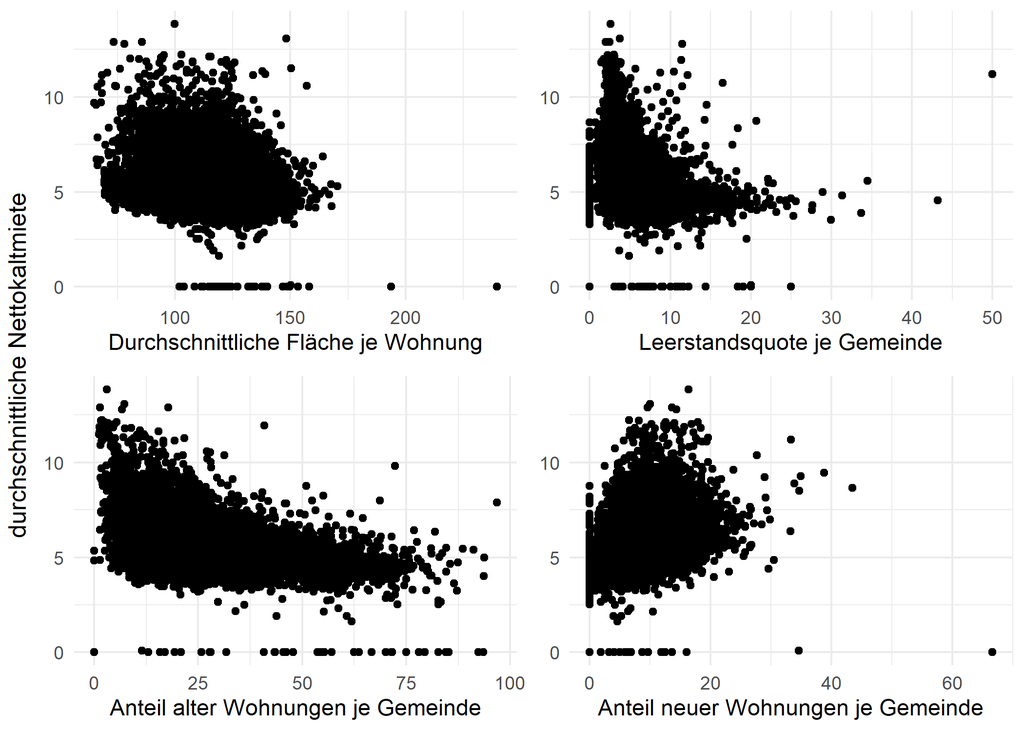

**Beschreibung**  
Die Punktdiagramme stellen die durchschnittliche Nettokaltmiete pro Quadratmeter im Verhältnis zur durchschnittlichen Fläche je Wohnung, der Leerstandsquote je Gemeinde, zum Anteil alter Wohnungen je Gemeinde und zum Anteil neuer Wohnungen je Gemeinde dar. Zu jedem der genannten Verhältnisse gibt es ein eigenes Diagramm.  
Dabei wird die Nettokaltmiete pro Quadratmeter auf der y-Achse dargestellt mit einer Range von 0-15.  
Die jeweils andere Größte steht auf der x-Achse. Wobei die durchschnittliche Fläche je Wohnung eine Range von 50 bis 250 hat, die Leerstandsquote je Gemeinde eine von 0-50, der Anteil alter Wohnungen je Gemeinde eine von 0 bis 100 und der Anteil neuer Wohnungen je Gemeinde eine Range von 0-70.

**Interpretation**  
Besonders stark scheinen vorallem die Variablen der Leerstandsquote je Gemeinde und der Anteil alter Wohnungen je Gemeinde auf die durchschnittliche Nettokaltmiete Einfluss zu nehmen. Bei einer geringen Leestandsquote ist die Nettokaltmiete relativ hoch. Steigt die Leerstandsquote sinkt auch die durchschnittliche Nettokaltmiete. Dies weißt auf ein typisches Nachfrage-Preis-Verhältniss hin. Sind Wohnungen mehr gefragt bzw. gibt es weniger freie Wohnungen, sind potentielle Mieter dazu bereit deutlich höhere Preise zu zahlen.  
Bei einem großen Anteil an neuen Wohnungen in der Gemeinde sind die durchschnittlichen Nettokaltmieten auch höher. Steigt der Anteil der alten Wohnungen innerhalbt der Gemeinde, so sinkt die durchschnittliche Nettokaltmiete. Potentielle Mieter sind meist eher bereit höhere Preise für neue Wohnungen zu bezahlen, da diese einige Vorteile gegenüber alten Wohungen haben. Wie beispielsweise moderne Sanitär- und Heizanlagen, bessere Dämmung und oft auch eine allgemein bessere Energieeffizienz.

Weiterhin wäre es von Interesse in die einzelnen Großstädte Deutschlands genauer hineinzuschauen, um dort auf Besonderheiten im Wohnmarkt einzugehen. Im ersten Schritt sollen Sie Eigenschaften in Bezug auf die Wohnungen genauer untersucht werden, um zu verstehen, welche Faktoren den Mietpreis innerhalb der urbanen Räume beeinflussen könnten. Anschließend wäre es von Interesse, auch die demografischen Merkmale der Mieterinnen und Mieter in den Blick zu nehmen. Dabei stellt sich die Frage, ob und in welchem Maße diese Einfluss auf die Mietpreise und deren Struktur nehmen.

In der vorherigen Aufgabe wurden Zusammenhänge zwischen dem Alter von Wohnungen und dem Mietpreis auf Gemeindeebene untersucht. Nun soll der Fokus darauf liegen, wie sich die Wohnungen in größeren Städten hinsichtlich ihres Alters verteilen.

8. Erstellen Sie ein Balkendiagramm für alle nachfolgenden Städte: `Stuttgart, Landeshauptstadt`, `Ulm, Universitätsstadt`, `Düsseldorf, Stadt`, `Berlin, Stadt`. Betrachten Sie dabei, wie das Alter der Wohnungen zwischen den Städten variiert. Sie sollen analysieren, wie groß der Anteil der Wohnungen abhängig nach den jeweiligen Baujahrsgruppen in den Städten ist. Tragen Sie in ihrem Balkendiagramm den *Anteil der Wohnungen nach den Baujahren* (auf der y-Achse) gegeben der *Baujahre für jede Stadt* (auf der x-Achse) ab.

Beschreiben und interpretieren Sie die Grafik. Haben Sie diese Unterschiede erwartet? Begründen Sie warum oder warum nicht.

*Hinweis:* Denken Sie daran das Faktorvariablen in ggplot hilfreich sein können.

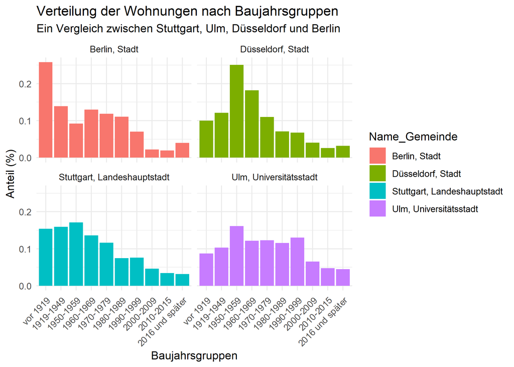

**Beschreibung**  
Die Grafik zeigt die Verteilung der Wohnungen nach Baujahrsgruppen in den Städten Stuttgart, Ulm, Düsseldorf und Berlin. Jede Stadt wird in einem eigenen Diagramm (Facet) dargestellt.

**Interpretation nach Städten**  
Berlin:  
In Berlin gibt es einen relativ hohen Anteil an sehr alten Wohnungen (“vor 1919” und “1919-1949”). Dies zeigt, dass ein Großteil der Wohnungen vor 1949 gebaut wurde, was typisch für eine historische Großstadt ist. Der Anteil moderner Wohnungen (“2010-2015” und “2016 und später”) ist vergleichsweise gering.

Düsseldorf:  
Die Verteilung zeigt einen Peak in den Baujahrsgruppen “1950-1959” und “1960-1969”, was auf eine starke Bautätigkeit zwischen 1950 und 1969 hinweist. Der Anteil älterer Wohnungen (“vor 1919” und “1919-1949”) ist moderat, während die neueren Baujahrsgruppen (“2010-2015” und “2016 und später”) nur einen geringen Anteil ausmachen.

Stuttgart:  
Die Verteilung ist relativ ausgewogen, wobei sowohl ältere als auch neuere Wohnungen vertreten sind. Auffällig ist der moderate Rückgang im Anteil neuer Wohnungen (“2010-2015” und “2016 und später”), was auf eine relativ konstante Bautätigkeit schließen lässt.

Ulm:  
Ulm zeigt einen deutlich höheren Anteil an modernen Wohnungen (“1990-1999” bis “2016 und später”) im Vergleich zu den anderen Städten. Dies könnte auf eine jüngere Stadtstruktur und eine höhere Bautätigkeit in den letzten Jahrzehnten hindeuten.

**Erwartung des Unterschieds**  
Ja, die Unterschiede sind größtenteils erwartbar, da sie die Geschichte und Entwicklung der Städte widerspiegeln.

9. Wie in der vorherigen Aufgabe zu sehen war, unterscheidet sich die Situation in Städten in Bezug auf die jeweiligen Baujahre der Wohnungen deutlich. Es wäre noch spannend zu sehen, ob auch das Alter der Bewohner, die Familienstände, oder die Einwanderungshistorie der Bewohner mit unterschiedlichen Mietpreisen assoziiert sind. Hier sollen Sie in einem ersten generellen Schritt ein paar demografische Faktoren einbeziehen, inwiefern diese eine Auswirkung haben. Betrachten Sie folgende Eigenschaften genauer:
- Familienstand
- Alter der Bewohner
- Einwanderungsgeschichte

Erstellen Sie eine oder mehrere passende Diagramme oder Grafiken für die in Aufgabe 8 aufgeführten Städte.

Beschreiben und interpretieren Sie diese. Haben Sie diese Unterschiede erwartet? Begründen Sie warum oder warum nicht. Wo gibt es Ihrer Ansicht nach besondere Auffälligkeiten? Warum kann es bei der unterschiedlichen Einteilung der Altersgruppen zu Problemen kommen? Was wären Möglichkeiten, um etwaige Probleme zu vermeiden?

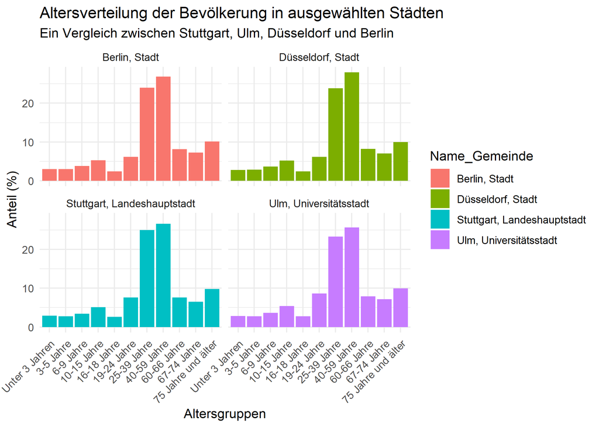

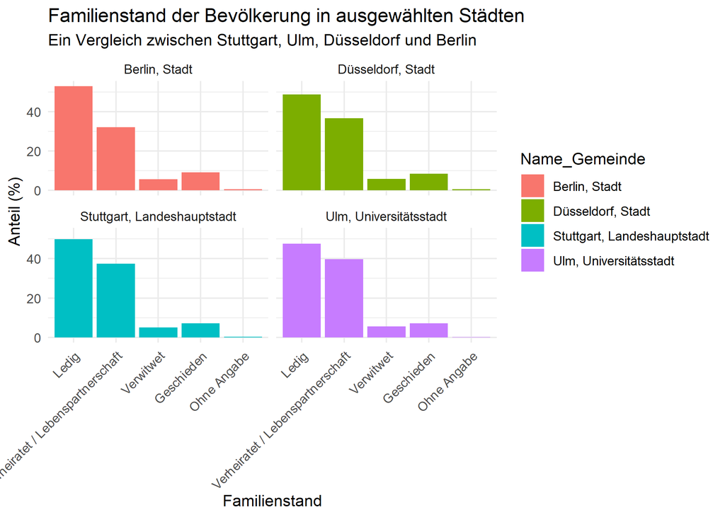

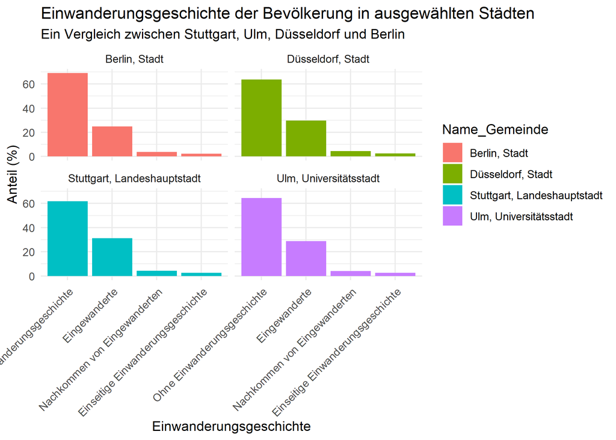

**Altersverteilung der Bevölkerung**

Die erste Grafik zeigt die Altersverteilung in Stuttgart, Ulm, Düsseldorf und Berlin. x-Achse: Altersgruppen, aufgeteilt in spezifische Intervalle von „Unter 3 Jahren“ bis „75 Jahre und älter“. y-Achse: Prozentualer Anteil der jeweiligen Altersgruppe an der Gesamtbevölkerung der Stadt. Auffällig ist Folgendes:

Auffallend ist der hohe Anteil in den Altersgruppen 25–39 und 40–59 Jahre. Dies könnte auf die starke Wirtschaft und die damit verbundenen Arbeitsmöglichkeiten für Menschen im erwerbsfähigen Alter hinweisen. Ulm:

In Ulm ist die Altersgruppe 19–24 Jahre auffällig größer. Dies könnte auf die Rolle der Stadt als Universitätsstadt zurückzuführen sein, die viele junge Menschen anzieht. Interpretation: Die Altersverteilung zeigt, dass wirtschaftliche und bildungsbezogene Faktoren (z. B. Universitäten oder Arbeitsmöglichkeiten) eine große Rolle spielen. Die Unterschiede zwischen den Städten sind erwartbar und spiegeln deren Charakteristika wider. Allerdings könnte die hohe Konzentration bestimmter Altersgruppen Herausforderungen für die städtische Infrastruktur und den Wohnungsmarkt darstellen.

**Familienstand der Bevölkerung**  
Die zweite Grafik zeigt den Familienstand der Bevölkerung in den vier Städten. x-Achse: Verschiedene Familienstandsgruppen: „Ledig“, „Verheiratet“, „Verwitwet“, „Geschieden“, „Ohne Angabe“. y-Achse: Prozentualer Anteil der jeweiligen Familienstandsgruppe an der Gesamtbevölkerung.

Berlin:  
Ein großer Anteil der Bevölkerung ist ledig, was typisch für eine Großstadt mit einem hohen Anteil an jungen und berufstätigen Menschen ist. Der Anteil an verheirateten Personen ist im Vergleich zu anderen Städten niedriger.

Düsseldorf:  
Ähnlich wie Berlin gibt es einen hohen Anteil lediger Personen. Der Anteil verheirateter Personen ist etwas höher als in Berlin, aber immer noch relativ niedrig.

Stuttgart:  
Hier ist der Anteil verheirateter Personen höher als in Berlin und Düsseldorf. Stuttgart weist eine ausgewogenere Verteilung zwischen ledigen und verheirateten Personen auf.

Ulm:  
Ulm hat den höchsten Anteil an verheirateten Personen im Vergleich zu den anderen Städten. Dies könnte mit der stärkeren Familienorientierung in kleineren Städten zusammenhängen. Interpretation: Die Unterschiede im Familienstand könnten mit dem Lebensstil und den sozioökonomischen Bedingungen in den Städten zusammenhängen. In Großstädten wie Berlin und Düsseldorf leben mehr Menschen allein oder in nicht ehelichen Lebensgemeinschaften, während in kleineren Städten wie Ulm traditionelle Familienstrukturen stärker vertreten sind.

**Einwanderungsgeschichte der Bevölkerung**  
Die dritte Grafik zeigt die Einwanderungsgeschichte der Bevölkerung. x-Achse: Kategorien der Einwanderungsgeschichte: „Ohne Einwanderungsgeschichte“, „Eingewanderte“, „Nachkommen von Eingewanderten“, „Einseitige Einwanderungsgeschichte“. y-Achse: Prozentualer Anteil der jeweiligen Gruppe an der Gesamtbevölkerung.

Berlin:  
Ein großer Anteil der Bevölkerung hat keine Einwanderungsgeschichte. Es gibt jedoch auch einen signifikanten Anteil von Eingewanderten und deren Nachkommen.

Stuttgart:  
Stuttgart zeigt einen höheren Anteil an Eingewanderten und deren Nachkommen im Vergleich zu den anderen Städten. Dies könnte auf die starke Wirtschaft und die hohe Attraktivität für Arbeitsmigranten zurückzuführen sein.

**Probleme durch unterschiedliche Einteilungen**  
Unterschiedliche Alters- oder Einwanderungsdefinitionen könnten zu Inkonsistenzen bei Vergleichen führen. Ein konsistenter Vergleich erfordert standardisierte Definitionen und Kategorien.

**Möglichkeiten zur Problemvermeidung**  
Einheitliche Einteilungen für Altersgruppen und Migrationskategorien verwenden. Ergänzende Datenquellen nutzen, um die Kategorisierungen besser zu validieren. Analysen auf regionaler Ebene durchführen, um Variationen innerhalb der Städte besser zu erfassen.

In den bisherigen Analysen wurden demografische und wohnungsbezogene Faktoren in verschiedenen Städten Deutschlands untersucht. Dabei lag der Fokus darauf, wie diese Merkmale in unterschiedlichen Regionen das Mietpreisniveau und dessen Struktur beeinflussen. Aufbauend auf diesen Erkenntnissen soll der Blick nun gezielt auf den Vergleich zwischen Ost- und Westdeutschland gelenkt werden. Diese regionale Differenzierung ermöglicht es, potenzielle Unterschiede und Gemeinsamkeiten zwischen den beiden Landesteilen genauer zu analysieren. Insbesondere wird betrachtet, wie sich die Mietpreisstruktur in Ost- und Westdeutschland darstellt und ob sich hierbei spezifische Muster oder Abweichungen erkennen lassen.

10. Betrachten Sie nun die Städte `Dresden, Stadt`, `Chemnitz, Stadt`, `Stuttgart, Landeshauptstadt`, `Ulm, Universitätsstadt`,`Düsseldorf, Stadt`und `Berlin, Stadt`. Vergleichen Sie in einem ersten Schritt die Anzahl an Einwohnern, den Anteil an Menschen, die deutscher Herkunft sind, den Anteil an neuen und alten Wohnungen, sowie die durchschnittlichen Mietpreise. Erweitern Sie ihre Analyse um die durschnittlichen Wohnflächen.

Erstellen Sie für die genannten Städte eine deskriptive Tabelle. Beschreiben und interpretieren Sie diese. Beantworten Sie insbesondere folgende Fragen:

- In wie weit könnte das Alter der Wohnungen eine Rolle für den Mietpreis spielen?
- Gibt es Auffälligkeiten zwischen den einzelnen Städten in Bezug auf Herkunft der Bewohner, Einwohner und Größe der Wohnungen?
- Warum könnte es problematisch sein, wenn Sie die Städte als ein Ganzes betrachten?
- Sind Ihre Ergebnisse auf die ganze Stadt verallgemeinerbar?
- Was sind ihrer Meinung nach Faktoren, die die unterschiedlichen Mietpreise in Ost und West erklären?
- Welche Maßnahmen wären geeignet, um in Düsseldorf, Ulm und Stuttgart die Mietpreisstruktur anzupassen und bezahlbaren Wohnraum zu schaffen?

| Stadt | Bevölkerung_insgesamt | Anteil_deutscher_Bürger | Anteil_neue_Wohnungen | Anteil_alte_Wohnungen | QMMIETE | FLAECHE |
| --- | --- | --- | --- | --- | --- | --- |
| Düsseldorf, Stadt | 611258 | 77.24 | 5.78 | 22.11 | 9.24 | 77.56 |
| Stuttgart, Landeshauptstadt | 610458 | 74.30 | 6.57 | 31.33 | 10.39 | 79.76 |
| Ulm, Universitätsstadt | 127116 | 78.22 | 9.26 | 19.02 | 8.48 | 87.64 |
| Berlin, Stadt | 3596999 | 80.46 | 5.92 | 39.72 | 7.67 | 73.22 |
| Chemnitz, Stadt | 240078 | 90.23 | 3.18 | 41.03 | 5.26 | 71.33 |
| Dresden, Stadt | 557782 | 90.69 | 6.62 | 39.61 | 6.92 | 71.24 |

<sup>1</sup> Die westdeutschen Städte sind grau hinterlegt

| Deskriptive Tabelle Variable | Deskriptive Tabelle Mittelwert | Deskriptive Tabelle Standardabweichung | Deskriptive Tabelle Minimum | Deskriptive Tabelle Q25 | Deskriptive Tabelle Median | Deskriptive Tabelle Q75 | Deskriptive Tabelle Maximum |
| --- | --- | --- | --- | --- | --- | --- | --- |
| Bevölkerung_insgesamt | 957281.83 | 1309296.20 | 127116.00 | 319504.00 | 584120.00 | 611058.00 | 3596999.00 |
| Anteil_deutscher_Bürger | 81.86 | 6.95 | 74.30 | 77.48 | 79.34 | 87.79 | 90.69 |
| Anteil_neue_Wohnungen | 6.22 | 1.95 | 3.18 | 5.81 | 6.24 | 6.61 | 9.26 |
| Anteil_alte_Wohnungen | 32.14 | 9.65 | 19.02 | 24.41 | 35.47 | 39.69 | 41.03 |
| QMMIETE | 7.99 | 1.80 | 5.26 | 7.11 | 8.07 | 9.05 | 10.39 |
| FLAECHE | 76.79 | 6.33 | 71.24 | 71.80 | 75.39 | 79.21 | 87.64 |

**Beschreibung:**

Die deskriptive Tabelle enthält die Variablen „Bevölkerung insgesamt“, „Anteil deutscher Bürger“, „Anteil neue Wohnungen“, „Anteil alte Wohnungen“, „Quadratmetermiete“ und „Fläche“. Für jede dieser Variablen werden die Kennzahlen Mittelwert, Standardabweichung, Minimum, Quartile (Q25, Median, Q75) und Maximum bereitgestellt.

Die durchschnittliche „Bevölkerung insgesamt“ beträgt 957.282 Menschen und zeigt mit einer hohen Standardabweichung von 1.309.296 eine große Variation, wobei die bevölkerungsreichste Stadt 3.596.999 Einwohner hat.  
Der „Anteil deutscher Bürger“ liegt im Durchschnitt bei 81,86%, bei einer Bandbreite von 74,3% bis 90,69%.  
Bei den Wohnungen sind im Schnitt 6,22% als „neue Wohnungen“ klassifiziert, wobei diese Zahl in den Städten von 3,18% bis 9,26% schwankt. „Alte Wohnungen“ machen durchschnittlich 32,14% aus, mit einem minimalen Anteil von 19,02% und einem maximalen von 41,03%.  
Die durchschnittliche „Quadratmetermiete“ liegt bei 7,99 Euro, mit Preisen zwischen 5,26 und 10,39 Euro.  
Die durchschnittliche „Fläche“ beträgt 76,79 Quadratmeter, variiert aber in den Städten zwischen 71,24 und 87,64 Quadratmetern.

Die Tabelle gibt somit eine umfangreiche Auskunft über demografische und wohnungsbezogene Merkmale in den analysierten Städten.

**Interpretation:**  
In wie weit könnte das Alter der Wohnungen eine Rolle für den Mietpreis spielen?  
Das Alter der Wohnungen scheint einen Einfluss auf die Mietpreise zu haben, da Wohnungen in Städten mit einem höheren Anteil an alten Gebäuden tendenziell niedrigere Mietpreise aufweisen. Beispielsweise hat Chemnitz den höchsten Anteil an alten Wohnungen (41,03%) und den niedrigsten Quadratmeterpreis (5,26 Euro). Älteren Gebäuden könnte es an moderner Technik und Sanitäranlagen fehlen und damit günstiger sein, während neuere Gebäude aufgrund moderner Ausstattung und höherer Energieeffizienz teurer sind. Allerdings gibt es auch Beispiele in der Tabelle, die auf das Gegenteil hinweisen, wie zum Beispiel Stuttgart, wo trotz eines noch relativ hohem Anteil an alten Wohnungen (31,33%) die Quadratmetermiete mit 10,39 Euro am höchsten ist. Dies deutet darauf hin, dass das Alter der Wohnungen zwar eine Rolle spielen kann, aber nicht zwangsweiße der ausschlaggebende Faktor für die Mietpreise ist, da auch andere Faktoren wie Standort, Nachfrage und städtische Infrastruktur eine wesentliche Rolle spielen können.

Warum könnte es problematisch sein, wenn Sie die Städte als ein Ganzes betrachten?  
Städte haben meist sehr große Varianzen in den Mieten und anderen wesentlichen Kennzahlen je nach Stadtteil. Betrachtet man die Städte als Ganzes, übersieht man möglicherweise wesentliche Aspekte und macht so falsche Schlussfolgerungen.

Sind Ihre Ergebnisse auf die ganze Stadt verallgemeinerbar?  
Die Ergebnisse sind höchstwahrscheinlich nicht für die gesamte Stadt verallgemeinerbar. Unterschiedliche Stadtteile können z.B. stark variierende soziale, wirtschaftliche und bauliche Strukturen aufweisen. Damit einhergehend können die einzelnen Stadtteile unterschiedliche Probleme aufweisen, welche einzeln für die bestimmten Stadtteile gelöst werden müssen. Dennoch geben die vorliegenden Daten einen groben Überblick über die Städte und sind vorallem für den Ost-/Westvergleich interessant.

Was sind ihrer Meinung nach Faktoren, die die unterschiedlichen Mietpreise in Ost und West erklären?  
Ein Großteil der Faktoren sind historischer Natur und beruhen auf der deutschen Teilung in die BRD und die damalige DDR. Der Osten litt während dieser Zeit unter massivsten wirtschatlichen Problemen. In der BRD gab es dagegen bereits in den 1950er einen massiven Aufschwung in der Wirtschaft, wodurch Westdeutschland wieder relativ schnell zu einem wirtschatlichen global Player wurde. Diese Gesamtwirtschafliche Lage hatte natürlich auch Auswirkungen auf die Wohnsituation der Menschen. Aber auch nach der Wiedervereinigung ging es dem Osten Deutschlands nicht zwangsweise besser. Ostdeutsche Städte erlebten einen massiven Rückgang in den Bevölerungszahlen, da die Einwohner zu großen Zahlen in den wirtschatlichen stabileren Westen zogen. Bis heute gibt es immer noch massive Unterschiede in der wirtschaftlichen Lage zwischen Ost und West. Daher sind Wohnungen in westlichen Städten oft weniger gefragt als in westlichen, wodurch hier nicht so hohe Preise verlangt werden können. Zudem könnten Investitionen in Modernisierung in den westlichen Städten auch höhere Mietpreise rechtfertigen.

Welche Maßnahmen wären geeignet, um in Düsseldorf, Ulm und Stuttgart die Mietpreisstruktur anzupassen und bezahlbaren Wohnraum zu schaffen?  
Um mehr bezahlbaren Wohnraum in diesen Städten zu schaffen gibt es verschiedene Ansatzpunkte. Einer wäre es den sozialen Wohnungsbau zu fördern und vermehrt in öffentliche Wohnungsprojekte zu investieren. So könnte man erschwinglichen Wohnraum für verschiedene Einkommensgruppen schaffen. Außerdem wäre die Einführung oder die Anpassung von Mietpreiskontrollen eine Überlegung wert. So könnte man zum Beispiel eine Mietpreisbremse, sowie strengere Regulierungen bei Bestandswohnungen einführen, welche die Mietpreisspirale dämpfen könnten. Auch Anreize druch zum Beispiel Steuererleichterungen für private Investoren könnten zu mehr Wohnungsbau führen. Diese Anreize könnte man dann an bestimmte Mietpreisbremsen knüpfen, wodurch erschwinglicher Wohnraum entstehen würde.

11. Lesen Sie den [folgenden Artikel](https://www.tagesschau.de/wirtschaft/sozialwohnungen-bau-mangel-101.html). Dort werden Sozialwohnungen thematisiert, warum so viele fehlen und wer davon vor allem betroffen ist. Beantworten Sie anschließend folgende Fragen:
- Welche Bevölkerungsgruppen sind am stärksten von der Sozialwohnungsnot betroffen und inwiefern?
- Was sind Gründe, warum es zu wenige Sozialwohnungen gibt?
- Wie sieht die historische Entwicklung des Sozialwohnungsbaus aus, im Hinblick auf Vorhandensein von Wohnungen und Investitionen in den Bau von neuen Wohnungen?
- Welche Anreize könnten Investoren motivieren, mehr Sozialwohnungen zu bauen?
- Welche innovativen Ansätze können Bauherren verfolgen, um die Kosten für den Wohnungsbau zu senken?

Vorallem die sozial schwächeren Bevölerungsgruppen sind von der sozialen Wohnungsnot betroffen. Auf dem gesamten Wohnungsmarkt steigen aufgrund des knapper werdenden Angebots an Wohnung die Preise. Dadurch ist es für sozial schwache Familien fast unmöglich eine bezahlbare Wohnung zu finden. Selbst ein Wohnberechtigungsschein hilft diesen Familien oft nicht. Es sind nicht genug Sozialwohnungen da, was dazu führt, dass diejenigen auf Wartelisten gesetzt werden.  
Die Gründe für die geringe Anzahl an Sozialwohnungen sind zum Großteil finanzieller Art. Bauen wird immer teurer, Gründe hierfür sind zum Beisspiel hohe Darlehenszinsen, hohe Preise, fehlende Fachkräfte am Bau. Nicht zuletzt hat auch die Ukrainekrise und die daraus resultierenden Schwierigkeiten mit den Lieferketten lässt die Preise für Bauvorhaben steigen. Darüber hinaus scheint die Regierung nicht genug für die Förderung von sozialen Bauprojekten zu tun. So waren im Jahr 2022 100.000 neue Sozialwohnungen geplant. Am Ende des Jahres gab es etwa 27.000 Sozialwohnungen weniger als im Jahr zuvor.  
Allgemein sieht die historische Entwicklung des Sozialwohnungsbaus, im Hinblick auf Vorhandensein von Wohnungen und Investitionen in den Bau von neuen Wohnungen schlecht aus. So gab es in den neunziger Jahren ca. drei Millionen Sozialwohnungen. Dagegen sind es heute nur noch rund 1,1 Millionen. Auch neue Bauprojekte sind nur wenige geplant. So melden viele Städte, “dass die laufenden Baustellen noch abgearbeitet werden, neue Projekte aber kaum geplant sind”. Wie groß die Zahl ist welche an sozialen Wohnungen gebraucht wird variiert. Laut Verena Bentle, der Präsidentin des Sozialverbandes VdK leigt sie bei etwas 5 Millionen. Die Zahl sei in den letzten Jahren auch gestiegen, da viele Familien in eine finanzielle Schieflage geraten sind. Soziale Wohnungen werden also immer mehr benötigt, während immer weniger davon entstehen, bzw. es sogar weniger werden.  
Um Investoren zu motivieren, mehr Sozialwohnungen zu errichten gibt es verschiedene Wege. Zum einen müsste der Staat deutlich mehr Förderungen für den sozialen Wohnungsbau bereit stellen. Aber auch der Abbau von Auflagen und schnellere Genehmigungen könnten das Bauen von sozialen Wohnungen wieder attraktiver für Investoren machen.  
Es gibt verschiedene innovative Ansätze um die Kosten für den Wohnungsbau zu senken. Einige Beisspiele nennt Jan Eitel, Gesellschafter der Immprinzip GmbH in dem Artikel: kleinere Treppenhäuser, verringerte Wandstärke, Holzbau, Flachdächer ohne Attika und auch der Schallschutz müsse nicht weiter verbessert werden, weil dieser schon ausreichend sei.

12. Gerade die Politik ist gefordert, bezahlbaren Wohnraum zu realisieren. Dabei gibt es eine Viezahl an politischen Maßnahmen, die aufgestellt wurden und umfangreich diskutiert werden. Betrachten Sie die folgenden Maßnahmen, welche helfen sollen, die angespannte Lage auf dem Mietmarkt zu entlasten. Argumentieren Sie, warum diese Maßnahmen sinnvoll/nicht sinnvoll sind und in welcher Art und Weise diese umgesetzt werden können.
1. “Fachleute fordern, die Regulierung von Bestandsmieten zu lockern, damit sich ihr Niveau den Neuvertragsmieten annähert, mehr Menschen umziehen und sich Wohnraum besser verteilt.”
2. “Eine weitere Möglichkeit wäre, Mieterhöhungen bei Neuvertragsmieten zu begrenzen.”
3. “Am einfachsten ist es, wenn vor allem in Großstädten, wo bezahlbarer Wohnraum fehlt, mehr gebaut wird.”
4. “Am besten wäre es, wenn zukünftig mehr Vermieter in regelmäßigen Abständen die Miete anpassen.”

**1) “Fachleute fordern, die Regulierung von Bestandsmieten zu lockern, damit sich ihr Niveau den Neuvertragsmieten annähert, mehr Menschen umziehen und sich Wohnraum besser verteilt.”**  
Die Regulierung von Bestandsmieten zu lockern könnten durchaus dazu führen, dass sich der Wohnraum besser verteilt. Es besteht aber ein sehr hohes Risiko, dass vorallem einkommenschwächere Mieter durch diese Lockerungen gezwungen wären umzuziehen. Langjährige Mieter würden damit aus ihren Wohnungen verdrängt werden. Dies könnte zu sozialen Spannungen führen. Allgemein ist von dieser Idee also eher abzuraten, da sie vorallem finanziell Schwache benachteiligt und es ungewiss ist ob die Maßnahme tatsächlich zu einer signifikant besseren Wohnraumverteilung führen würde oder ob sie lediglich die Mietpreise insgesamt erhöht.

**2) “Eine weitere Möglichkeit wäre, Mieterhöhungen bei Neuvertragsmieten zu begrenzen.”**  
Diese Maßnahme würde überzogene Mieten verhindern und könnte damit tatsächlich für mehr erschwinglichen Wohnraum sorgen. Zudem würde diese Maßnahme den Markt stabilisieren und spekulative Mietpreisanstiege vermeiden.  
Dennoch ist diese Maßnahme nicht einwandfrei. Eine begrenzte Mieterhöhung bei Neuvertragsmieten würde höchstwahrscheinlich in einem Investitionsrückgang enden. Dadurch würden weniger neue Wohnungen entstehen, was sich negativ auf den gesamten Wohnungsmarkt auswirken würde. Zudem hätten die Vermieter auch weniger Motivation in die Renovierung ihrer Wohnungen zu investieren.

**3) “Am einfachsten ist es, wenn vor allem in Großstädten, wo bezahlbarer Wohnraum fehlt, mehr gebaut wird.”**  
Diese Maßnahme erscheint auch recht sinnvoll. Mehr Wohnungsbau führt zu einem größeren Wohnungsangebot, das helfen kann, den Preisdruck auf dem Mietmarkt zu reduzieren, indem die Nachfrage besser gedeckt wird. Zudem könnten Neubauten dazu beitragen, unterschiedliche Wohnformen zu schaffen, die den Bedürfnissen verschiedener Bevölkerungsgruppen entsprechen. Außerdem stellt der Wohnungsbau in Großstäden auch eine langfristige Lösung dar. Der langfristige Bedarf an Wohnungen, der sehr wahrscheinlich in Großstädten in der Zunkunft zunehmen wird, könnte so gedeckt werden. Aber auch diese Maßnahme kommt nicht ohne einige Nachteile. So benötigt man für neuen Wohnungsbau eine große Anzahl an freien Flächen, dies könnte in Konflikt mit Zielen des Flächensparens und Naturschutzes stehen. Auch für die Infrastruktur stellt neuer Wohnungsbau oft eine Belastung dar. Außerdem benötigen Bauprojekte dieser Art meist eine lange Zeit an Planung und auch die Umsetzung kann meist mehrere Jahre in Anspruch nehmen. Auch Bürokratie ist oft ein Hinderniss bei solchen Bauprojekten. Die Errichtung von neuem bezahlbarer Wohnraum in Großstädten stellt also eher eine langfristige Lösung dar, kann aber dennoch als sinnvoll angesehen werden.

**4) “Am besten wäre es, wenn zukünftig mehr Vermieter in regelmäßigen Abständen die Miete anpassen.”**  
Diese Maßnahme zielt daraufhin ein gleichmäßigeres Mietpreiswachstum zu gewährleisten. Dies würde vorallem die Vorhersehbarkeit und Planbarkeit steigern. Da große Mietpreissprünge vermeiden werden würden. Zudem wäre der Wohnungsmarkt so weniger anfällig für spekulative Mietpreiserhöhungen. Die reglmäßige Anpassung an Mietpreisen würde für die Mieter aber dennoch eine Belastung darstellen. Auch wenn sie gering ausfällt kann eine fortwährende Erhöhung der Miete, vorallem für Haushalte mit geringem einkommen eine Belastung darstellen. Ob diese Maßnahme sinnvoll ist, ist daher auch davon abhängig wie oft und wie hoch diese Mieterhöhungen ausfallen würden.

# Einzelne Stadtteile in Deutschland

In allen vorherigen Aufgaben haben Sie die Städte, Gemeinden oder auch Landkreise immer als ein Ganzes betrachtet. Jedoch ist es schwierig gerade in Großstädten wie Berlin, Düsseldorf oder auch Stuttgart allgemeine Aussagen über die Mietsituation auf Stadtebene zu treffen. Dies liegt unter anderem daran, dass unterschiedliche Stadtviertel unterschiedliche demografische Eigenschaften, sowie eine unterschiedliche Mietstruktur aufweisen können. Hier wäre es sinnvoll sich mit dem Stadtbild und der Verteilung der Mieten genauer auseinanderzusetzen, um zu sehen, wie sich Mieten innerhalb der Stadt verteilen. Wie in Aufgabe 10 zu sehen war, weisen die Städte im Westen Deutschlands untereinander, sowie die Städte im Osten ähnliche Merkmale auf, weshalb Sie sich in den folgenden Aufgaben auf je eine große und eine kleinere Stadt aus beiden Regionen konzentrieren.

13. In dieser Aufgabe sollen Sie ihren Datensatz aus Aufgabe 4, bei dem Sie Kartendaten und Informationen zu Mieten und LEQ auf 1km-Gitterebene heruntergeladen und zusammengefügt haben, verwenden und vier Karten zeichnen, welche die Verteilung der Nettokaltmieten in den Stadtteilen der Städte “Stuttgart, Landeshauptstadt”, “Ulm, Universitätsstadt”, “Chemnitz, Stadt” und “Dresden, Stadt” anschaulich visualisieren.

Erstellen Sie vier Grafiken, beschreiben und interpretieren diese. Gehen Sie insbesondere auf folgende Fragen ein:

- Welche Besonderheiten fallen Ihnen bei diesen Städten auf?
- Gibt es eine Segregation in Bezug auf die Mieten in einzelnen Stadtteilen?
- Falls es eine Segregation gibt, welche Konsequenzen könnte dies haben?
- Welche Rolle spielen geografische oder infrastrukturelle Faktoren bei den Mietpreisen?
- Gibt es Unterschiede zwischen Städten im Osten und Westen Deutschlands, falls ja, welche Einflüsse in Bezug auf Wirtschaft und Arbeitsmarkt könnte dies in den jeweiligen Städten haben?

*Hinweis:* Wenn Sie einheitliche Legenden für die Karten haben möchten und die vier Städte nebeneinander oder untereinander darstellen wollen, so empfiehlt sich das Paket `ggpubr` und dort der Befehl `ggarrange`.

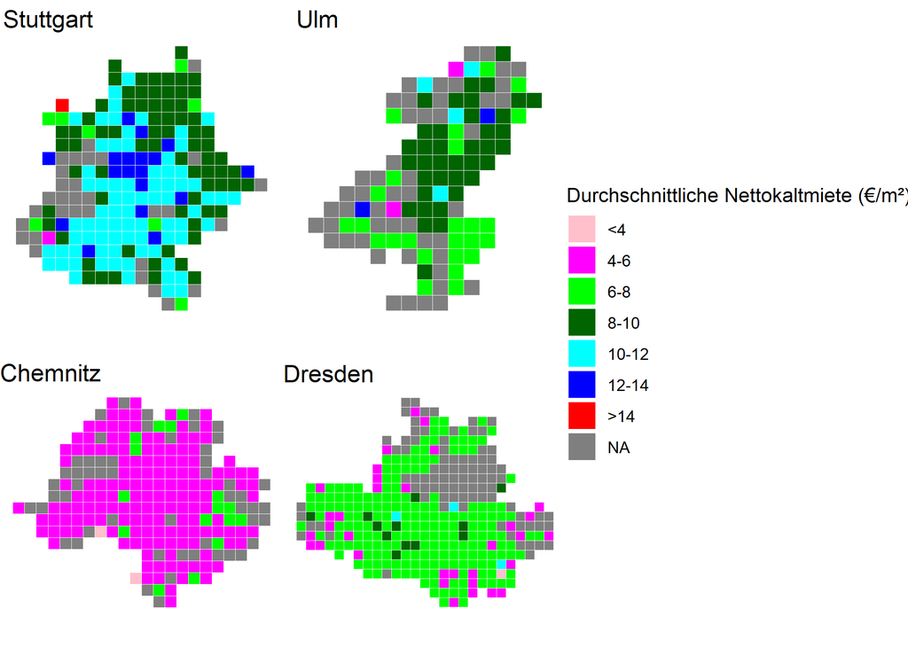

**Beschreibung:**  
Die Grafiken stellen die vier Städte Stuttgart, Ulm, Chemnitz und Dresden dar. Diese sind aufgeteilt in 1km mal 1km große Kasten. Diese Kasten sind jeweils eingefärbt, entsprechend der durchschnittlichen Kaltmiete pro Quadratmeter.  
Anhand der legende auf der rechten Seite lässt sich erkennen, dass die durschnittliche Kaltmiete in Chemnitz und in Dresden generell geringer ausfällt als in Stuttgart und Ulm. Chemnitz ist hierbei fast vollständig pink eingefärbt, was einer durchschnittlichen Kaltmiete von 4-6€ pro Quadratmeter entspricht. Dresden ist fast vollständig hellgrün eingefärbt, was einer durchschnittlichen Kaltmiete von 6-8€ pro Quadratmeter entspricht. In Dresden lässt sich zudem ein relativ großer grau eingefärbter Fleck erkennen. Dies zeigt auf, dass es für dieses Gebiet keine Daten gibt. Stuttgart und Ulm sind nicht so einheitlich eingefärbt wie Chemnitz und Dresden. In Stuttgart ist der größte Teil hellblau eingefärbt, was einer durchschnittlichen Kaltmiete von 10-12€ pro Quadratmeter entspricht. Zudem ist auch ein großer Teil dunkelgrün (8-10€ pro Quadratmeter) und ein zentraler Felck ist dunkelblau (12-14€ pro Quadratmeter) gefärbt. In Ulm ist der größte Teil dunkelgrün gefärbt (8-10€ pro Quadratmeter). Einige Teile Ulms sind zudem hellgrün (6-8€ pro Quadratmeter). Auch in Ulm lassen sich sehr viele graue Kasten (keine Daten) finden. In alles Städten gibt es “Ausreißer” also vereinzelte Kasten in anderen Farben, welche vom Großteil der jeweiligen Stadt abweichen.

**Interpretation:**  
Die sehr einheitliche Färbung der Städte Chemnitz und Dresden stellen einen Kontrast zu der “bunteren” Einfärbung der Städte Ulm und Stuttgart dar. Die Mieten sind hier also ortsunabhänig relativ konsistent. Es gibt in Chemnitz und Dresden also sogut wie keine Segregation in Bezug auf die Mieten. Hingegen ist eine solche Segregation durchaus in Ulm und Stuttgart vorzufinden. Eine solche Segregation führt oft zu sozialer Ungleichheit, da Geringverdiener in weniger attraktive Stadtteile abgedrängt werden. Diese Trennung kann den Zugang zu wichtigen Dienstleistungen wie Bildung und Gesundheitsversorgung erschweren und wirtschaftliche Disparitäten verstärken, indem sie den Zugang zu Arbeitsmärkten reduziert. Auch das soziale Gefüge kann leiden, da betroffene Personen sich isoliert und ausgeschlossen fühlen könnten. Dies kann politische Spannungen vergrößern.  
Geografische oder infrastrukturelle Faktoren können massive Auswirkungen auf die Mietpreise haben. Zentral gelegene Wohnungen mit guter Verkehrsanbindung sind aufgrund hoher Nachfrage oft teurer. Die Nähe zu Infrastruktureinrichtungen wie Schulen, Krankenhäusern und Einkaufsmöglichkeiten erhöht ebenfalls den Mietwert, da sie die Lebensqualität steigern. Umweltfaktoren wie Grünflächen oder eine niedrige Kriminalitätsrate tragen zur Attraktivität bei und können die Preise weiter anheben.  
Die bereits erwähnten Unterschiede in den Mietpreisen weisen auf eine deutlich stärkere Wirtschaft in den westlichen Städten hin. Hier sind die Mietpreise höher, da die Bewohner sich aufgrund besser bezahlter Jobs auch teurere Wohnungen leisten können. Die quasi einheitliche Färbung in den Oststädten könnte ein Zeichen für die homogene Nachfrage an Wohnungen sein. Es gibt in diesen Städten keine großen Unterschiede im Verdienst der Einwohner wodurch auch die Mieten relativ konstant ausfallen. Zudem sind dann auch die Wohnungen relativ gleich. Es gibt also nur begrenzt Unterschiede in der Qualität der Wohnungen und ihrer Lage. Diese Unterschiede würden unterschiedliche Mietpreise rechtfertigen.

14. Nachdem Sie in Aufgabe 13 die Verteilung der Mieten der einzelnen Stadtteile visualisiert haben, sollten Sie in dieser Aufgabe den Anteil der Leerstandsquoten in den Stadtteilen der Städte “Stuttgart, Landeshauptstadt”, “Ulm, Universitätsstadt”, “Chemnitz, Stadt” und “Dresden, Stadt” veranschaulichen.

Erstellen Sie vier Grafiken, beschreiben und interpretieren diese. Gehen Sie insbesondere auf folgende Fragen ein:

- Was könnten Gründe sein, dass die Leerstandsquote in bestimmten Stadtteilen höher ist, als in anderen?
- Welche Besonderheiten fallen Ihnen bei diesen Städten auf? Auch im Hinblick auf ihre Erkenntnisse aus Aufgabe 13.
- Vergleichen Sie die Grafiken aus Aufgabe 13 und Aufgabe 14. Was könnte der Grund für die unterschiedlichen Muster sein?
- Welche Maßnahmen ergreifen Städte mit hohen Leerstandsquoten, um diese zu reduzieren?

*Hinweis:* Wenn Sie einheitliche Legenden für die Karten haben möchten und die vier Städte nebeneinander oder untereinander darstellen möchten, so empfiehlt sich das Paket `ggpubr` und dort der Befehl `ggarrange`.

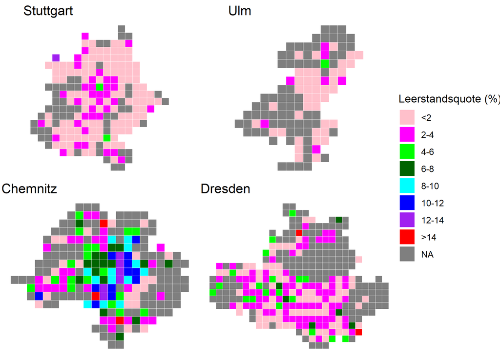

**Beschreibung:**  
Die Grafiken stellen die vier Städte Stuttgart, Ulm, Chemnitz und Dresden dar. Diese sind aufgeteilt in 1km mal 1km große Kasten. Diese Kasten sind jeweils eingefärbt, entsprechend der durchschnittlichen Leerstandsquote.  
Anhand der Legende auf der rechten Seite lässt sich erkennen, dass die Leerstandsquote in Ulm und Stuttgart zum größten Teil unter 2% liegt. Nur in Stuttgart gibt es zentral einen Fleck in dem die Leerstandsquote zu großen Teilen zwischen 2% und 4% liegt. In Chemnitz und Dresden ist die Leerstandsquote generell höher. In Dresden liegt sie in großen Teilen zwischen 2 und 4% und vereinzelt auch zwischen 4 und 6%. In Chemnitz ist sie sogar noch höher. Hier lassen sich vorallem zentral sehr hohe Leerstandsquoten festellen. Sie liegen hier je nach Kasten zwischen 4% bis teilweise sogar 14%.  
In allen Städten gibt es einige graue Kasten, für diese sind keine Daten vorhanden.

**Interpretation:**  
Es gibt verschiedene Gründe warum die Leerstandsquote in bestimmten Stadtteilen höher ist, als in anderen. Die Stadtteile in denen die Leerstandsquote höher ist, sind möglicherweise nicht so attraktiv für Mieter. Dies könnte daran liegen, dass die Infrastruktur und Anbindung an den öffentlichen Nahverkehr schlecht ist. Gebiete schlechter öffentlicher Verkehrsanbindung oder fehlender Infrastruktur wie Geschäfte, Schulen und Gesundheitsdienste sind oft weniger begehrt. Die Wohnungen in diesen Gebieten könnten sich zudem in einem schlechten Zustand befinden und wären somit unattraktiver für potentielle Miete.  
Auffällig ist dass die Leerstandsquoten in den Städten in Ostdeutschland tendenziell höher sind als die in den westlichen Städten. Trotz der generell niedrigerer Mieten welche in Aufgabe 13 verglichen wurden, gibt es hier also weniger Menschen die in diesen Städten wohnen wollen. Dies liegt wahrscheinlich vorallem an wirtschaftlichen Faktoren. Im Westen gibt es meist besser bezahlte Jobs wodurch einige Menschen eher vom Osten in den Westen ziehen. Dadurch sinkt die Nachfrage nach Wohnungen im Osten und im Westen steigt sie. Dadurch sind Bewohner in des westlichen Städten teilweise gezwungen auch Wohnungen zu mieten, welche sehr teuer sind. So bleibt so gut wie keine Wohnung unbewohnt.  
Vorallem in Chemnitz ist das Muster der Aufgabe 13 und 14 sehr unterschiedlich. In Aufgabe 13 ist die Färbung der Stadt nahezu homogen, während sie in Aufgabe 14 sehr bunt ist. Da die Mieten in fast allen Stadtteilen gleich ist, wie man aus Aufgabe 13 entnehmen kann, muss es andere Gründe für die unterschiedlichen Leerstandsquoten geben, welche man in Aufgabe 14 sieht. Die Stadtteile mit einer höheren Leestandsquote sind möglicherweise trotz des gleichen Preises unattraktiver als die anderen Stadtteile. Dies könnte an Faktoren liegen welche am Anfang des Textes erläutert wurden. Also zum Beispiel strukturelle unterschiede in der Infrastruktur und Anbindung.  
Um gegen hohe Leerstandsquoten vorzugehen, gibt es verschiedene Möglichkeiten. Für die meisten muss die Stadt Geld investieren. So kann die Stadt beispielsweise die Infrastruktur ausbauen, um so den Nahverkehr, Schulen und Freizeiteinrichtungen zu verbessern. Aber auch die Wohnungen selber können durch Sanierung und Modernisierung attraktiver gemacht werden. Hier können dann auch finanzielle Anreize und Förderprogramme für Eigentümer helfen. Steuerliche Anreize sind auch eine gute Möglichkeit um Wohngebiete mit hoher Leerstandsquote wieder attraktiver für Mieter zu machen.

15. Die aktuellen Mietpreise und deren Entwicklungen hindern in Deutschland immer mehr Menschen daran, dass sie sich eine neue geeignete Wohnung suchen. Personen, die aufgrund ihrer aktuellen Lebenssituation sich nach einer neuen Wohnung umsehen, finden oft keine oder können sich diese nicht leisten. Doch worin liegen die Ursachen und Probleme?

Beantworten Sie hierzu folgende Fragen:

- Was versteht man unter dem Lock-in-Effekt, speziell in Bezug auf den Mietmarkt? Wer ist davon vor allem betroffen und warum?
- Gibt es aktuell Möglichkeiten, die vor allem diese “betroffenen” Personen haben, um an bezahlbaren Wohnraum zu gelangen?
- Worin liegen die Ursachen, dass Bestandsmieten (Mieten aus bestehenden Verträgen) und Angebotsmieten (Mieten aus Neuverträgen) so stark voneinander abweichen?

Gehen Sie in ihrer Argumentation auch auf die Grafiken und Ergebnisse der Aufgaben 11, 13 und 14 ein.

**Was versteht man unter dem Lock-in-Effekt, speziell in Bezug auf den Mietmarkt? Wer ist davon vor allem betroffen und warum?**  
Der Lock-in-Effekt im Mietmarkt beschreibt die Situation, in der Mieter in ihren bestehenden Mietverträgen “gefangen” sind, weil sie sich einen Umzug zu den aktuell höheren Mieten auf dem Markt nicht leisten können. Dieser Effekt führt dazu, dass Mieter trotz veränderter Anforderungen oder Wünsche an ihre Wohnsituation in ihrer derzeitigen Wohnung verbleiben. Von diesem Effekt sind vorallem einkommenschwache Haushalte betroffen, da sie nur einen geringen finaziellen Spielraum haben, um die in der Regel höheren Mieten von Wohnungen zu begleichen, die besser an ihre aktuellen Bedürfnisse angepasst sind.

**Gibt es aktuell Möglichkeiten, die vor allem diese “betroffenen” Personen haben, um an bezahlbaren Wohnraum zu gelangen?**  
Theoretisch wären Sozialwohnungen für solche Haushalte eine Möglichkeit um an bezahlbaren Wohnraum zu gelangen. Wie sich aber in Aufgabe 11 gezeigt hat gibt es derzeit in Deutschland nicht genügend sozialen Wohnraum. Dadurch sind diese Haushalte gezwungen in Wohnungen zu bleiben, welche nicht ihren Bedürfnissen gerecht werden. Der Lock-in-Effekt bleibt hier also bestehen. Eine weitere Möglichkeit wäre es theoretisch in eine andere Stadt zu ziehen. Personen welche unter dem Lock-in-Effekt in zum Beispiel Stuttgart leiden könnten theoretisch in eine der in Aufgabe 13/14 besprochenen östlichen Städte ziehen. Dies ist meistens aber auch keine Möglichkeit, da mit dem Wohnplatz auch meistens der Arbeitsplatz einhergeht. Das bedeutet würden diese Menschen umziehen müssten sie neben ihrem sozialen Umfeld auch ihren wahrscheinlich besser als im OSten bezahlten Arbeitsplatz aufgeben.  
Es gibt derzeit also nur sehr begrenzte Möglichkeiten für sozial schwache Haushalte dem Lock-in-Effekt zu entkommen.

**Worin liegen die Ursachen, dass Bestandsmieten (Mieten aus bestehenden Verträgen) und Angebotsmieten (Mieten aus Neuverträgen) so stark voneinander abweichen?**  
Bestandsmieten sind meist deutlich geringer als Angebotsmieten. Dies liegt vorallem and Mietregulierungen und Mietpreisbindungen.Bestandsmieten unterliegen häufig unterschiedlichen Regulierungen, wie etwa der Mietpreisbremse oder gesetzlichen Mieterhöhungsgrenzen, die verhindern, dass die Mieten in bestehenden Verträgen schnell steigen. Diese Regulierungen wirken als Schutzmechanismen für Mieter und halten die Mieterhöhungen oft unter dem Marktniveau.  
Zudem wird die Angebotsmiete meist der aktuellen Marktnachfrage angepasst und ist somit in Zeiten hoher Nachfrage und knappem Angebot relativ hoch.  
Zudem sollen die relativ niedrigen Bestandsmieten auch einen Anreiz für Mieter darstellen. Da Vermieter einen Vorteil haben, wenn sie stabile Mietverhältnisse erhalten, da kontinuierlich vermietete Wohnungen das Risiko von Leerstandskosten mindern und Verwaltungskosten für häufige Mieterwechsel einsparen.

# Stadt vs. Land

Bisher haben Sie sich intensiv mit der Wohnsituation in Deutschland auseinandergesetzt und dabei insbesondere die Unterschiede zwischen Ost- und Westdeutschland betrachtet. Im Fokus standen dabei die Mietpreisentwicklung und die Rolle verschiedener Faktoren wie demografische Merkmale, Leerstandsquote, Eigentümerquote, sowie die Wohnfläche. Diese Analysen haben wertvolle Erkenntnisse über die regionale Dynamik des Mietmarkts geliefert.

Nun sollen Sie ihren Blickwinkel erweitern und den Fokus auf eine weitere Ebene der Analyse richten. Im Kern sollen Sie den Unterschied zwischen städtischen Regionen, insbesondere Großstädten, und ländlichen Gebieten untersuchen. Hierbei soll die Mietstruktur in diesen beiden Raumtypen analysiert werden, ob sich die Strukturen von Stadt und Land voneinander unterscheiden.

16. Betrachten Sie in einem ersten Schritt die Wohnungen abhängig ihres Alters. Erstellen Sie dazu eine passende Grafik, die die Verteilung der Wohnungen nach Altersgruppen für die Stadt `Stuttgart, Landeshauptstadt` (Landkreis: Stuttgart, Stadtkreis) im Vergleich zum `Alb-Donau-Kreis` und `Ostalbkreis` darlegt.

Beschreiben und interpretieren Sie ihre Grafik. Woran könnte es liegen, dass es in Stuttgart (in der Stadt) deutlich mehr Altbauwohnungen als auf dem Land gibt? Könnten politische Maßnahmen ihrer Ansicht nach helfen, dass auch in Großstädten mehr neue Wohnungen erbaut und zur Vermietung zur Verfügung gestellt werden?

*Hinweis 1:* Nutzen Sie für die Visualisierung einen Mosaik- oder ein “stacked” Balkendiagramm. Eine Idee, wie Sie das Ganze darstellen können, finden Sie [hier](https://r-graph-gallery.com/).

*Hinweis 2:* Für Stuttgart soll der komplette Landkreis (“Stadtkreis”) untersucht werden.

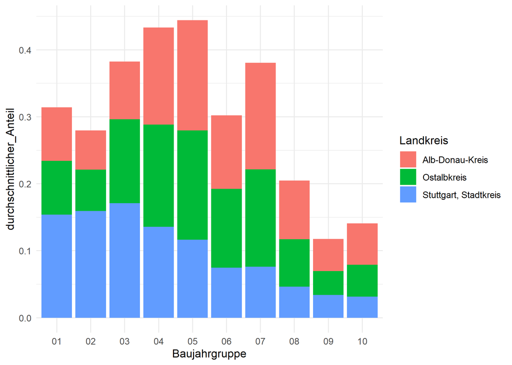

**Interpretation:**  
Dass es in Stuttgart mehr Altbauwohnungen gibt, als auf dem Land hat mehrere Gründe. Städte wie Stuttgart haben meist eine lange historische Bebauungsgeschichte. Viele dieser Gebäude wurden vor mehreren Jahrzehnten errichtet und prägen bis heute das Stadtbild. Zudem gibt es in Städten wie Stuttgart oft eine relativ hohe Bebauungsdichte, wodurch es nur beschränkt Möglichkeiten gibt neue Gebäude zu errichten. Dies ist auf dem Land in der Regel nicht der Fall, da es dort genügend freie Flächen gibt für Neubauten. Außerdem stehen die Altbauwohnungen in Städten wie Stuttgart oftmals unter Denkmalschutz. Dies fördert ihre Erhaltung und Restaurierung.  
Politische Maßnahmen könnten helfen, dass auch in Großstädten mehr neue Wohnungen erbaut und zur Vermietung zur Verfügung gestellt werden. Durch steuerliche Anreize und Zuschüsse könnten Investitionen in neuen Wohnungsbau wirtschaftlich attraktiver gestaltet werden. Zudem würde auch eine Vereinfachung von Bauvorschriften und Verkürzung von Genehmigungsverfahren helfen Bauvorhaben zu beschleunigen und attraktiver zu machen. Um gegen das Problem der Knappheit an neuen Bauflächen in Städten wie Stuttgart vorzugehen könnte man Brachen nutzen, bestehende Bauten aufstocken und Gewerbeflächen zu Wohnflächen umbauen. Zudem könnte man durch den Ausbau von Infrastruktur in neu zu entwickelnden Gebieten, diese Gebiete attraktiver für Investoren und Mieter machen.

In einem weiteren Schritt sollen Sie nun die Mietpreise und deren Verteilung analysieren. Hierbei sollen Sie neben der Leerstands- und Eigentümerquote auch auf die Verteilung der Wohnungen nach deren Wohnfläche achten und diese untersuchen.

17 (a). Erstellen Sie zuerst eine Tabelle, die die durchschnittlichen Mietpreise mit der Leerstands- und Eigentümerquote darstellt. Was fällt ihnen dabei besonders auf? Beschreiben und interpretieren Sie ihre Tabelle.

17 (b). Erstellen Sie eine weitere Grafik, die die Verteilung der Wohnungen nach den einzelnen Wohnungsgrößen(<40m² bis >=200m²) abbildet. Stellen Sie darüber hinaus den durchschnittlichen Mietpreis je Landkreis in einer weiteren Grafik dar. Beschreiben und interpretieren Sie ihre Grafiken. Gehen Sie insbesondere auf die Frage ein, ob es Sinn macht sich vor allem den Ostalbkreis oder Alb-Donau-Kreis als ein Ganzes anzusehen und inwieweit überhaupt ein Vergleich zwischen Stadt und ländlicher Region möglich ist.

*Hinweis:* Hier sollen Sie erneut auf dieselben Städte und Landkreise aus Aufgabe 16 eingehen!

| Mittelwerte Landkreis | Mittelwerte Kaltmiete | Mittelwerte Leerstandsquote | Mittelwerte Eigentümerquote |
| --- | --- | --- | --- |
| Alb-Donau-Kreis | 6.37 | 5.34 | 71.44 |
| Ostalbkreis | 6.27 | 5.09 | 70.59 |
| Stuttgart, Stadtkreis | 10.39 | 3.46 | 31.15 |

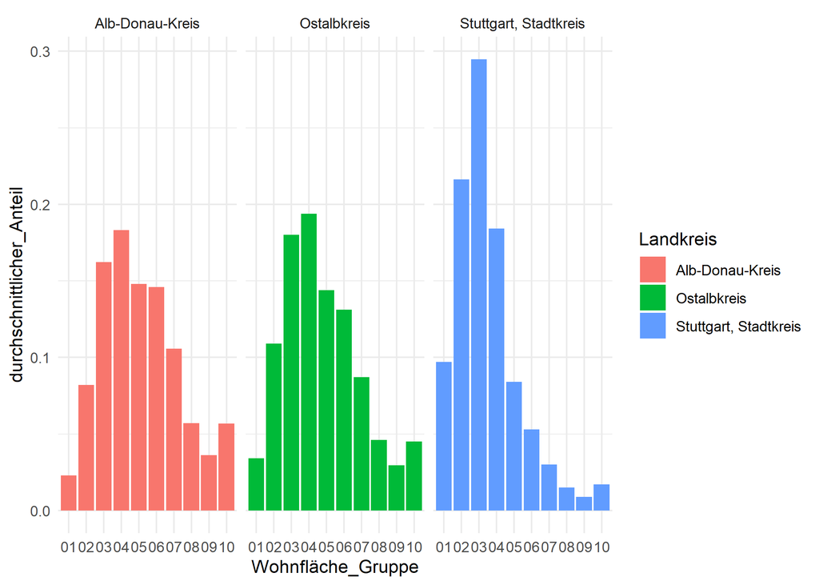

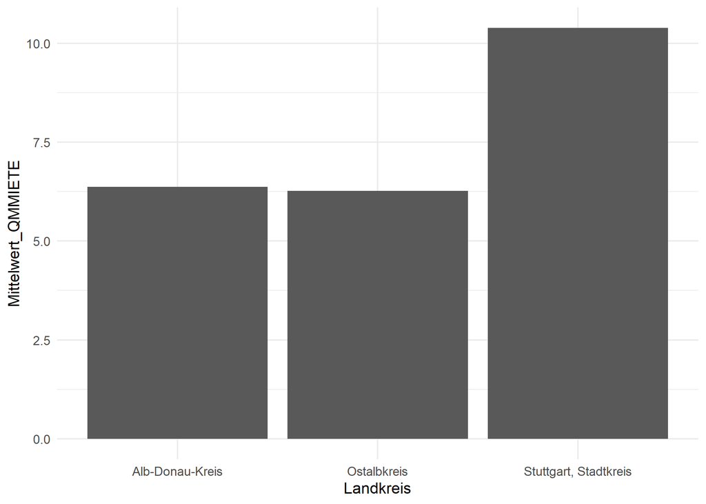

**Aufgabe 17(a)**  
**Beschreibung:**  
Die vorliegende Tabelle zeigt die durchschnittliche Kaltmiete pro Quadratmeter, die Leerstandsquote und die Eigentümerquote für die Landkreise “Alb-Donau-Kreis”, “Ostalbkreis” und “Stuttgart, Stadtkreis”.  
Während die Werte aller drei Variablen im Alb-Donau-Kreis und im Ostalbkreis relativ ähnlich sind, lassen sich in Stuttgart deutlich andere Werte finden. Die Miete ist in Stuttgart (10,39€ pro Quadratmeter) deutlich höher, als in den beiden anderen Kreisen (6,37€ bzw 6,27€ pro Quadratmeter). Die Leerstandsquote in Stuttgart (3,46%) ist dabei deutlich geringer als in den anderen beiden Kreisen (5,34% und 5,09%). Selbes gilt für die Eigentümerquote, diese liegt in Stuttgart bei 31,15 und in den anderen Kreisen bei 71,44% bzw. 70.59%.

**Interpretation:**  
Die relativ hohe Miete und die relativ geringe Leerstandsquote in Stuttgart zeigt auf, dass Wohnraum hier deutlich mehr gefragt ist als auf dem Land. Aufgrund der höheren Nachfrage sind Vermieter in der Lage deutlich höhere Preise zu verlangen. Zudem sind Mieter hier, aufgrund des knapperen Wohnungsangebots auch eher gewillt “in den saueren Apfel zu beißen” und Wohnungen zu nehmen, welche nicht 100% ihren Anforderungen entsprechen. Hierdurch ergibt sich dann auch die geringere Leerstandsquote. Die geringe Eigentümerquote in Stuttgart weißt zudem darauf hin, dass hier Wohnraum vermehrt als eine Investition angesehen wird. Außerdem könnte dies auch ein Hinweis darauf sein, dass Wohnungen vermehrt von großen Konzernen bzw. Gesellschaften gehalten werden. Zudem weißt sie auch auf einen demografischen Faktor hin. Großstädte ziehen meist eine jüngere, mobilere Bevölkerung an, die eher zur Miete wohnt, während in ländlichen Gebieten mehr Familien und ältere Menschen leben, die Wohneigentum bevorzugen.

**Aufgabe 17(b)**  
**Beschreibung:**  
Das erste Balkendiagramm zeigt die durchscnittlichen Anteile je Wohnflächengruppe für “Stuttgart, Stadtkreis”, “Ostalbkreis” und den “Alb-Donau-Kreis”. Dabei lässt sich die Wohnflächengruppe auf der x-Achse und der durschnittliche Anteil auf der y-Achse finden.  
Die Verteilung der beiden ländlichen Landkreisen (Alb-Donau-Kreis und Ostalbkreis) ist hier relativ ähnlich. In beiden liegt der Fokus vorallem zwischen den Wohnflächengruppen 03-06. Wo bei sie das Maximum bei ca. 18% beziehungsweise 19% haben, in der Wohnflächengruppe 04. Stuttgart hat seinen Fokus in etwas kleineren Wohnflächengruppen (02-04). Zudem hat Stuttgart in diesen Wohnflächengruppen aber deutlich größere prozentuale Anteile. Hier liegt das Maximum bei ca. 29% in der Wohnflächengruppe 03. Stuttgart hat also deutlich weniger große Wohnungen, beziehungsweise deutlich mehr kleine Wohnungen als die beiden ländlichen Landkreise.

Das zweite Balkendiragramm zeigt den durchschnittlichen Mietpreis je Landkreis. Hierbei lässt sich der jeweilige Landkreis auf der x-Achse und der Mittelwert der Quadratmetermiete auf der y-Achse finden.  
Es lässt sich erkennen, dass die Miete in den ländlichen Landkreisen relativ ähnlich ist und bei ca. 6,30€ pro Quadratmeter liegt. Die durchschnittliche Miete in Stuttgart liegt hingegen deutlich höher, bei ca. 10,30€ pro Quadratmeter.

**Interpretation:**  
In beiden Grafiken sind die Werte des Alb-Donau-Kreises und des Ostalbkreises relativ ähnlich. Also zumindest im Vergleich zu Stuttgart mach es durchaus Sinn die beiden Landkreise als ein Ganzes zusehen.  
Es lässt sich deutlich erkennen dass die Wohnsituation in Stuttgart eine komplett andere ist als in den beiden Kreisen. In Stuttgart sind die Mietpreise deutlich höher, wodurch sich die Mieter nicht so große Wohnungen wie in den ländlichen Kreisen leisten können. Dadurch lassen sich in Stuttgart vermehrt eher kleine Wohnungen finden, wie man der ersten Grafik entnehmen kann.

Generell ist es zwar möglich, einen Vergleich zwischen Stadt und ländlicher Region zu machen, aber dieser Vergleich muss die grundlegenden Unterschiede in wirtschaftlicher Dynamik, Infrastruktur und Lebensweise berücksichtigen. Städte zeichnen sich typischerweise durch eine höhere Bevölkerungsdichte, eine stärkere wirtschaftliche Dynamik und eine diversifizierte Arbeitsplatzstruktur aus. Diese Faktoren ziehen ein breiteres Spektrum an Arbeitskräften an und bieten umfangreiche Bildungs- und Berufsmöglichkeiten. Die infrastrukturelle Erschließung ist in städtischen Gebieten umfangreicher, was den Zugang zu Dienstleistungen, Kulturangeboten und öffentlichen Verkehrsmitteln erleichtert. Gleichzeitig gehen diese Vorzüge oft mit höheren Lebenshaltungskosten einher, insbesondere bei Miet- und Immobilienpreisen.  
Im Gegensatz dazu bieten ländliche Regionen eine geringere Bevölkerungsdichte und häufig eine stärkere Fokussierung auf Landwirtschaft oder spezifische Industrien. Diese Gebiete zeichnen sich durch niedrigere Lebenshaltungskosten aus, was auf günstigere Immobilienpreise und Alltagskosten zurückzuführen ist. Jedoch ist die Infrastruktur oft weniger ausgeprägt, was den Zugang zu Dienstleistungen wie medizinischer Versorgung oder öffentlichem Nahverkehr erschwert. Diese Unterschiede führen dazu, dass ländliche und städtische Gebiete unterschiedliche Herausforderungen und Chancen aufweisen.  
Daher erfordert der Vergleich zwischen Stadt und ländlicher Region einen differenzierten Ansatz. Dieser Ansatz sollte die individuellen Stärken und Schwächen jeder Region beleuchten, um effektive Strategien für eine ausgewogene Entwicklung zu entwickeln. Solche Strategien könnten darauf abzielen, die wirtschaftliche Entwicklung zu fördern, die Infrastruktur zu verbessern und die Lebensqualität in beiden Gebieten zu steigern, indem die spezifischen Bedürfnisse und Potenziale berücksichtigt werden.

# Zusatzfrage (optional)

Diese Frage ist von der Bearbeitung her etwas schwieriger. Bevor Sie sich an diese Aufgabe machen, sollten Sie sicherstellen, dass Sie alle vorherigen Fragen ausführlich beantwortet haben. Eine korrekte Beantwortung dieser Frage gibt einen Punktebonus von 3 Punkten (das Projekt umfasst insgesamt 30 Punkte, inkl. Screencast).

Nachdem Sie sich in den bisherigen Aufgaben ausführlich mit den allgemeinen Einflussfaktoren auf die Mietpreise befasst haben, rückt nun ein spezifischer Aspekt in den Fokus: die Rolle der Heizungen. Insbesondere werden Sie untersuchen, wie unterschiedliche Heizungsarten und -systeme die Mietpreise beeinflussen können. Diese Betrachtung ermöglicht es ihnen, die bisherigen Analysen zu verfeinern und den Zusammenhang zwischen energetischen Standards und der Entwicklung von Mietkosten genauer zu erfassen. Aufgabe 18 führt Sie somit zu einem weiteren zentralen Detail der Mietpreisentwicklung, das insbesondere vor dem Hintergrund steigender Energiepreise und der Relevanz nachhaltiger Wohnformen an Bedeutung gewinnt.

18. Lesen Sie den Datensatz `Heiztypen_Zensus.csv` ein und speichern diesen als `heiztypen` ab. Neben den Ihnen bekannten Variablen, finden Sie dort 6 weitere Variablen, die Auskunft über die Heizarten der jeweiligen Wohnung geben. Diese werden wie folgt beschrieben:
- HEIZTYP__1: Gebäude mit Heizungsart Fernheizung (Fernwärme) (Anzahl)
- HEIZTYP__2: Gebäude mit Heizungsart Etagenheizung (Anzahl)
- HEIZTYP__3: Gebäude mit Heizungsart Blockheizung (Anzahl)
- HEIZTYP__4: Gebäude mit Heizungsart Zentralheizung (Anzahl)
- HEIZTYP__5: Gebäude mit Heizungsart Einzel- oder Mehrraumöfen (auch Nachtspeicherheizung) (Anzahl)
- HEIZTYP__6: Gebäude mit Heizungsart Keine Heizung im Gebäude oder in den Wohnungen (Anzahl)

Erstellen Sie eine neue Spalte `heiztypen_gesamt`, welche die Summe über alle Heiztypen hinweg bildet. Bestimmen Sie weiterhin den Anteil der jeweiligen Heiztypen je Gemeinde (als Anteil aller Heizarten). Nun sollen Sie eine oder mehrere passende Grafik(en) erzeugen, die je nach durchschnittlicher Größe der Wohnungen die Anteile der verschiedenen Heizungsarten abbilden. Erstellen Sie weiterhin eine oder mehrere passende Grafik(en) die den Zusammenhang zwischen den Heizungsarten und den durschnittlichen Mietpreisen darstellt. Wiederum soll der Anteil der verschiedenen Heizungsarten abhängig der Mietpreise abgebildet werden.

Beschreiben und interpretieren Sie ihre Schaubilder und gehen Sie insbesondere auf folgende Frage ein:

- Gibt es einen Zusammenhang zwischen der Heizungsart und der Größe der Wohnungen?
- Gibt es einen Zusammenhang zwischen der Heizungsart und den Mietpreisen?
- Was könnten Gründe sein, warum in bestimmten Wohnungsgrößen eher bestimmte Heizungstypen eingebaut werden und andere nicht?
- Warum könnte es sein, dass bei manchen Heizungsarten die Mietpreise höher sind als bei anderen?
- Was könnte die Bundesregierung machen, um trotz neuer und moderner Heizungssysteme die Mietpreise nach oben hin zu beschränken?

*Hinweis 1:* Überlegen Sie sich, ob es ihrer Ansicht nach Sinn macht, die jeweiligen Wohnungsgrößen und durchschnittlichen Mietpreise in Segmente zu unterteilen.

*Hinweis 2:* Eine Möglichkeit die Beziehung zwischen Heizungsarten und Wohnungsgrößen bzw. Heizungsarten und Mietpreisen zu visualisieren wäre beispielsweise ein “stacked” oder “grouped” Balkendiagramm. Überlegen Sie sich, warum diese Form der Darstellung besonders gut geeignet wäre.

Wie Sie in der Aufgabe 15 gesehen haben, haben Ulm und Stuttgart, sowie Dresden und Chemnitz ähnliche Verhältnisse bezüglich der Verteilung der Mietkosten über die Stadt hinweg. Aufgrund dessen beschränken Sie sich bei dieser Aufgabe auf die Städte Stuttgart und Dresden. Hier sollen Sie sich die einzelnen Heizungsarten über die Stadtteile hinweg anschauen, wie sich diese verteilen und ob hier Ähnlichkeiten zur Mietpreissstrukur vorliegt. Weiterhin sind vor allem die Heizungsarten Fernwärme, Zentralheizung und Etagenheizung in viele deutschen Wohnungen größtenteils verbaut, weshalb Sie gerade deswegen diese drei Heiztypen genauer beleuchten und untersuchen sollen.

19. Deshalb sollten Sie sich in einem ersten Schritt [diese Geogitter-Daten für die verschiedenen Heinzungsarten vom statistischen Bundesamt herunterladen](https://www.zensus2022.de/static/Zensus_Veroeffentlichung/Zensus2022_Heizungsart.zip). Speichern Sie die zip-Datei im Ordner `Daten` ab. Nutzen Sie erneut den Datensatz shape_file aus der Aufgabe 4 und joinen Sie die Informationen zu den Heizungsarten über die Variablen `x_mp_1km` und `y_mp_1km`.

In ihrem Datensatz können Sie sehen, dass es Einträge mit “-” gibt. Diese sollen sie für alle Heizungstypen durch 0 ersetzen. Achten Sie auch darauf, dass über alle Heizungstypen hinweg die Werte als numeric vorliegen.

Erstellen Sie nun für die Heizungsarten “Fernheizung”, “Etagenheizung” und “Zentralheizung” eine neue Spalte mit dem Anteil des jeweiligen Heizungstyps an allen Heizungen (`Insgesamt_Heizungsart`) je Gemeinde. Schließlich sollen Sie nun für die drei genannten Heizungsarten eine Karte erzeugen, welche den Anteil je Gitterebene im Stadtbezirk darstellt.

Beschreiben und interpretieren Sie ihre Grafiken. Berücksichtigen Sie dabei insbesondere folgende Fragen:

- Wo liegen Besonderheiten oder Muster in beiden Städten?
- Gibt es in Stuttgart und Dresden Stadtteile, bei denen bestimmte Heizungstypen in Einklang mit den Mietpreisen stehen, genauer gesagt, welche Heizungsarten korrelieren mit höheren oder niedrigeren Mietpreisen? Vergleichen Sie dazu die Ergebnisse aus Aufgabe 15.
- Was könnten Gründe sein, dass in bestimmten Stadtteilen vorwiegend eine bestimmte Form der Heizung eingebaut ist?
- Gibt es Unterschiede zwischen Ost- und Westdeutschland?
- Haben die Städte Stuttgart oder Dresden in den letzen Jahren Modernisierungen angestoßen oder Neuerungen umgesetzt und finanziell unterstützt, sodass es dort zu größeren Anpassungen bei der Heizungstechnik kam?

*Hinweis 1:* Sie sollen insgesamt für jede Stadt (Stuttgart und Dresden) drei verschiedene Karten erzeugen.

*Hinweis 2:* Achten Sie auf eine sinnvolle Einteilung und Darstellung in den Karten. Nutzen Sie die Karten aus vorherigen Aufgaben als Hilfestellung.

Abschließend sollen Sie die Zusatzaufgabe noch einmal rekapitulieren und einige Fragen dazu beantworten.

20. Sie sollen sich noch einmal bewusst werden, was Sie in den vorherigen Aufgaben analysiert haben und in welcher Form ihre Ergebnisse anwendbar und verallgemeinbar sind. Beantworten Sie dazu Frage 1 und 2.

Frage 1: Betrachten Sie hierzu noch einmal exemplarisch die Städte Stuttgart und Dresden.

- Sind die Zusammenhänge zwischen Mietpreisen in den Städten und sozioökonomischer Faktoren vor allem auf Unterschiede zwischen den Städten oder auf Unterschiede innerhalb der Stadt zurückzuführen. Bei welchen Faktoren ist dies der Fall, wo nicht?
- Wie kann der Staat im Hinblick auf die unterschiedlichen Heizungsarten in den Städten eingreifen, um Wohnraum preiswerter zu gestalten?

Frage 2: Schauen Sie sich noch einmal die Verteilung der Heizungsarten (Fern-, Etagen- und Zentralheizungen) für Stuttgart und Dresden in Aufgabe 19 an. Betrachten Sie im Vergleich dazu ihre Grafik aus Aufgabe 8, sowie ihre Tabelle in Aufgabe 13?

- Was fällt Ihnen hier auf?
- Gibt es bestimmte Heizungstypen, die nur in alten oder neuen Wohnungen vorkommen?
- Welche Schlüsse würden Sie ziehen, die mit Handlungen der Politik einhergehen?